# Exploratory_analysis_BTS_Sample_Stage1_RR

Weibiao Liu

2024/01/26

This is an [R Markdown](http://rmarkdown.rstudio.com) file for Exploratory analysis of data analyses in the protocol of a meta research which aims at surveying sample characteristics of big team science in psychology.

In this script, we will use data from PSA 001 project [Jones et al., 2021, *Nature Human Behavior*](https://doi.org/10.1038/s41562-020-01007-2), and partial articles published in psychological science in 2014 [Red et al., 2018, *Proceedings of the National Academy of Sciences*](https://doi.org/10.1073/pnas.1721165115), and Ruggeri et al. (2022)[*Nature Human Behavior*](https://doi.org/10.1038/s41562-022-01392-w) to exemplify the analyses that we are going to use in our this project.

```r
library(tidyverse)        # ggplot, dplyr, %>%, and friends
library(brms)             # Bayesian modeling through Stan
library(marginaleffects)  # Calculate marginal effects for regression models
library(tidybayes)        # Manipulate Stan objects in a tidy way
library(patchwork)        # Combine ggplot objects
library(ggrepel)          # Automatically position labels
library(scales)           # Format numbers in nice ways
library(collapse)
library(broom)            # Convert model objects to data frames
library(broom.mixed)      # Convert brms model objects to data frames
library(extraDistr)       # Use extra distributions like dprop()
library(ggdist)           # Special geoms for posterior distributions
library(gghalves)         # Special half geoms
library(ggbeeswarm)       # Special distribution-shaped point jittering
library(modelsummary)     # Create side-by-side regression tables
library(ggthemes)
```

# Country-level

Country-level relationship between proportion of sample and socioeconomic/cultural factors for traditional studies (using PS2014 as an example) and big team science (using PSA 001 as an example)

## GDP_per_capita

```r
gdpdata <- read_csv("gdpdata.csv")
gdpdata
```

```
## # A tibble: 185 × 10
##    country country_map continent     GDP_per_capita   bts total_bts
##    <chr>   <chr>       <chr>                  <dbl> <dbl>     <dbl>
##  1 AND     AD          Europe                 42.0      0     11484
##  2 ARE     AE          Asia                   53.8     80     11484
##  3 ATG     AG          North America          18.7      0     11484
##  4 ARM     AM          Asia                    7.01     0     11484
##  5 AGO     AO          Africa                  3.00     0     11484
##  6 ARG     AR          South America          13.7     91     11484
##  7 AUT     AT          Europe                 52.1    236     11484
##  8 AUS     AU          Oceania                64.5    885     11484
##  9 AZE     AZ          Asia                    7.74     0     11484
## 10 BIH     BA          Europe                  7.59     0     11484
## # ℹ 175 more rows
## # ℹ 4 more variables: percentage_sample <dbl>, ps <dbl>, total_ps <dbl>,
## #   ps2014 <dbl>
```

### PSA001

```r
gdp_model_beta_zi_bts <- brms::brm(
   bf(bts| trials(total_bts) ~ GDP_per_capita,
   phi ~ GDP_per_capita,
     zi ~ GDP_per_capita),
  data = gdpdata,
  family = zero_inflated_beta_binomial(),
  chains = 4, iter = 2000, warmup = 1000,
  cores = 2, seed = 1234,

  backend = "cmdstanr",
  file = "gdp_model_beta_zi_bts"
)
tidy(gdp_model_beta_zi_bts, effects = "fixed")
```

```
## # A tibble: 6 × 7
##   effect component term               estimate std.error conf.low conf.high
##   <chr>  <chr>     <chr>                 <dbl>     <dbl>    <dbl>     <dbl>
## 1 fixed  cond      (Intercept)         -4.21     0.183   -4.58      -3.85
## 2 fixed  cond      phi_(Intercept)      5.38     0.347    4.64       6.00
## 3 fixed  zi        (Intercept)          2.24     0.324    1.64       2.91
## 4 fixed  cond      GDP_per_capita       0.0110   0.00710 -0.00252    0.0249
## 5 fixed  cond      phi_GDP_per_capita  -0.0445   0.00911 -0.0628    -0.0272
## 6 fixed  zi        GDP_per_capita      -0.0593   0.0146  -0.0887    -0.0317
```

```r
ame_beta_zi_gdp_bts <- gdp_model_beta_zi_bts %>%
  marginaleffects::avg_comparisons(variables = "GDP_per_capita") %>%
  marginaleffects::posterior_draws()
ame_beta_zi_gdp_bts %>% tidybayes::median_hdi(draw)
```

```
## # A tibble: 1 × 6
##    draw .lower .upper .width .point .interval
##   <dbl>  <dbl>  <dbl>  <dbl> <chr>  <chr>
## 1  2.39   1.07   4.43   0.95 median hdi
```

```r
result <-  brms::hypothesis(ame_beta_zi_gdp_bts, "draw>0")
result
```

```
## Hypothesis Tests for class :
##   Hypothesis Estimate Est.Error CI.Lower CI.Upper Evid.Ratio Post.Prob Star
## 1 (draw) > 0     2.58      0.95     1.43     4.36        Inf         1    *
## ---
## 'CI': 90%-CI for one-sided and 95%-CI for two-sided hypotheses.
## '*': For one-sided hypotheses, the posterior probability exceeds 95%;
## for two-sided hypotheses, the value tested against lies outside the 95%-CI.
## Posterior probabilities of point hypotheses assume equal prior probabilities.
```

### PS2014

```r
gdp_model_beta_zi_ps2014 <- brms::brm(
  bf(ps| trials(total_ps) ~ GDP_per_capita,
   phi ~ GDP_per_capita,
     zi ~ GDP_per_capita),
  data = gdpdata,
  family = zero_inflated_beta_binomial(),
  chains = 4, iter = 2000, warmup = 1000,
  cores = 4, seed = 1234,

  backend = "cmdstanr",
  file = "gdp_model_beta_zi_ps2014"
)
tidy(gdp_model_beta_zi_ps2014, effects = "fixed")
```

```
## # A tibble: 6 × 7
##   effect component term                estimate std.error conf.low conf.high
##   <chr>  <chr>     <chr>                  <dbl>     <dbl>    <dbl>     <dbl>
## 1 fixed  cond      (Intercept)        -4.16        0.599   -5.27     -2.89
## 2 fixed  cond      phi_(Intercept)     1.53        0.604    0.255     2.62
## 3 fixed  zi        (Intercept)         3.26        0.801    1.84      4.98
## 4 fixed  cond      GDP_per_capita      0.00472     0.0111  -0.0171    0.0260
## 5 fixed  cond      phi_GDP_per_capita  0.000138    0.0112  -0.0223    0.0227
## 6 fixed  zi        GDP_per_capita     -0.314       0.109   -0.566    -0.148
```

```r
ame_beta_zi_gdp_ps2014 <- gdp_model_beta_zi_ps2014 %>%
  marginaleffects::avg_comparisons(variables = "GDP_per_capita") %>%
  marginaleffects::posterior_draws()
ame_beta_zi_gdp_ps2014 %>% tidybayes::median_hdi(draw)
```

```
## # A tibble: 1 × 6
##    draw .lower .upper .width .point .interval
##   <dbl>  <dbl>  <dbl>  <dbl> <chr>  <chr>
## 1  6.21   2.30   12.9   0.95 median hdi
```

```r
result <- brms::hypothesis(ame_beta_zi_gdp_ps2014, "draw>0")
result
```

```
## Hypothesis Tests for class :
##   Hypothesis Estimate Est.Error CI.Lower CI.Upper Evid.Ratio Post.Prob Star
## 1 (draw) > 0     6.87         3     3.37    12.76        Inf         1    *
## ---
## 'CI': 90%-CI for one-sided and 95%-CI for two-sided hypotheses.
## '*': For one-sided hypotheses, the posterior probability exceeds 95%;
## for two-sided hypotheses, the value tested against lies outside the 95%-CI.
## Posterior probabilities of point hypotheses assume equal prior probabilities.
```

## R&D_investment

```r
rddata <- read_csv("rddata.csv")
rddata
```

```
## # A tibble: 70 × 10
##    country     R_D country_map continent   bts total_bts percentage_sample    ps
##    <chr>     <dbl> <chr>       <chr>     <dbl>     <dbl>             <dbl> <dbl>
##  1 United_A…  1.3  AE          Asia         80     11484           0.00697     0
##  2 Armenia    0.19 AM          Asia          0     11484           0           0
##  3 Austria    3.17 AT          Europe      236     11484           0.0206     33
##  4 Azerbaij…  0.18 AZ          Asia          0     11484           0           0
##  5 Bosnia H…  0.2  BA          Europe        0     11484           0          33
##  6 Belgium    2.82 BE          Europe       86     11484           0.00749   125
##  7 Bulgaria   0.77 BG          Europe        0     11484           0          33
##  8 Burundi    0.21 BI          Africa        0     11484           0           0
##  9 Brunei_D…  0.28 BN          Asia          0     11484           0           0
## 10 Belarus    0.61 BY          Europe        0     11484           0          33
## # ℹ 60 more rows
## # ℹ 2 more variables: total_ps <dbl>, ps2014 <dbl>
```

### PSA001

```r
rd_model_beta_zi_bts <- brms::brm(
  bf(bts| trials(total_bts) ~ R_D,
   phi ~ R_D,
     zi ~ R_D),
  data = rddata,
  family = zero_inflated_beta_binomial(),
  chains = 4, iter = 2000, warmup = 1000,
  cores = 2, seed = 1234,

  backend = "cmdstanr",
  file = "rd_model_beta_zi_bts"
)
tidy(rd_model_beta_zi_bts, effects = "fixed")
```

```
## # A tibble: 6 × 7
##   effect component term            estimate std.error conf.low conf.high
##   <chr>  <chr>     <chr>              <dbl>     <dbl>    <dbl>     <dbl>
## 1 fixed  cond      (Intercept)       -4.08      0.324   -4.69     -3.40
## 2 fixed  cond      phi_(Intercept)    5.19      0.580    3.95      6.16
## 3 fixed  zi        (Intercept)        2.50      0.626    1.37      3.87
## 4 fixed  cond      R_D                0.236     0.215   -0.177     0.659
## 5 fixed  cond      phi_R_D           -1.01      0.280   -1.54     -0.449
## 6 fixed  zi        R_D               -1.98      0.573   -3.26     -0.983
```

```r
ame_beta_zi_rd_bts <- rd_model_beta_zi_bts %>%
  marginaleffects::avg_comparisons(variables = "R_D") %>%
  marginaleffects::posterior_draws()
ame_beta_zi_rd_bts %>% tidybayes::median_hdi(draw)
```

```
## # A tibble: 1 × 6
##    draw .lower .upper .width .point .interval
##   <dbl>  <dbl>  <dbl>  <dbl> <chr>  <chr>
## 1  94.8   37.4   204.   0.95 median hdi
```

```r
result <- brms::hypothesis(ame_beta_zi_rd_bts, "draw>0")
result
```

```
## Hypothesis Tests for class :
##   Hypothesis Estimate Est.Error CI.Lower CI.Upper Evid.Ratio Post.Prob Star
## 1 (draw) > 0   105.69     48.89     50.4   198.04        Inf         1    *
## ---
## 'CI': 90%-CI for one-sided and 95%-CI for two-sided hypotheses.
## '*': For one-sided hypotheses, the posterior probability exceeds 95%;
## for two-sided hypotheses, the value tested against lies outside the 95%-CI.
## Posterior probabilities of point hypotheses assume equal prior probabilities.
```

### PS2014

```r
rd_model_beta_zi_ps2014 <- brms::brm(
  bf(ps| trials(total_ps) ~ R_D,
   phi ~ R_D,
     zi ~ R_D),
  data = rddata,
  family = zero_inflated_beta_binomial(),
  chains = 4, iter = 2000, warmup = 1000,
  cores = 2, seed = 1234,

  backend = "cmdstanr",
  file = "rd_model_beta_zi_ps2014"
)
tidy(rd_model_beta_zi_ps2014, effects = "fixed")
```

```
## # A tibble: 6 × 7
##   effect component term            estimate std.error conf.low conf.high
##   <chr>  <chr>     <chr>              <dbl>     <dbl>    <dbl>     <dbl>
## 1 fixed  cond      (Intercept)       -6.35      0.123   -6.61     -6.12
## 2 fixed  cond      phi_(Intercept)   11.4       0.818    9.83     13.1
## 3 fixed  zi        (Intercept)        2.08      0.598    0.988     3.35
## 4 fixed  cond      R_D                0.596     0.163    0.289     0.922
## 5 fixed  cond      phi_R_D           -3.33      0.363   -4.09     -2.67
## 6 fixed  zi        R_D               -3.16      0.830   -5.02     -1.74
```

```r
ame_beta_zi_rd_ps2014 <- rd_model_beta_zi_ps2014 %>%
  marginaleffects::avg_comparisons(variables = "R_D") %>%
  marginaleffects::posterior_draws()
ame_beta_zi_rd_ps2014 %>% tidybayes::median_hdi(draw)
```

```
## # A tibble: 2 × 6
##    draw .lower .upper .width .point .interval
##   <dbl>  <dbl>  <dbl>  <dbl> <chr>  <chr>
## 1  43.3   16.6   91.1   0.95 median hdi
## 2  43.3   92.5   96.9   0.95 median hdi
```

```r
result <- brms::hypothesis(ame_beta_zi_rd_ps2014, "draw>0")
result
```

```
## Hypothesis Tests for class :
##   Hypothesis Estimate Est.Error CI.Lower CI.Upper Evid.Ratio Post.Prob Star
## 1 (draw) > 0    49.61     24.95    23.51    95.34        Inf         1    *
## ---
## 'CI': 90%-CI for one-sided and 95%-CI for two-sided hypotheses.
## '*': For one-sided hypotheses, the posterior probability exceeds 95%;
## for two-sided hypotheses, the value tested against lies outside the 95%-CI.
## Posterior probabilities of point hypotheses assume equal prior probabilities.
```

## Number of universities per 100000 people

```r
universitydata <- read_csv("universitydata.csv")
universitydata
```

```
## # A tibble: 217 × 12
##    country1             country_map continent     number of universitie…¹    pop
##    <chr>                <chr>       <chr>                           <dbl>  <dbl>
##  1 Andorra              AD          Europe                              3 7.90e1
##  2 United Arab Emirates AE          Asia                               72 9.37e3
##  3 Afghanistan          AF          Asia                               96 4.01e4
##  4 Antigua and Barbuda  AG          North America                       3 9.32e1
##  5 Anguilla             AI          North America                       4 1.58e1
##  6 Albania              AL          Europe                             44 2.85e3
##  7 Armenia              AM          Asia                               51 2.79e3
##  8 Angola               AO          Africa                             23 3.45e4
##  9 Argentina            AR          South America                     146 4.53e4
## 10 American Samoa       AS          Oceania                             1 4.51e1
## # ℹ 207 more rows
## # ℹ abbreviated name: ¹`number of universities`
## # ℹ 7 more variables: number_of_universities_per_capita <dbl>, bts <dbl>,
## #   total_bts <dbl>, percentage_sample <dbl>, ps <dbl>, total_ps <dbl>,
## #   ps2014 <dbl>
```

### PSA001

```r
university_model_beta_zi_bts <- brms::brm(
  bf(bts| trials(total_bts) ~ number_of_universities_per_capita,
   phi ~ number_of_universities_per_capita,
     zi ~ number_of_universities_per_capita),
  data = universitydata,
  family = zero_inflated_beta_binomial(),
  chains = 4, iter = 2000, warmup = 1000,
  cores = 2, seed = 1234,

  backend = "cmdstanr",
  file = "university_model_beta_zi_bts"
)
tidy(university_model_beta_zi_bts, effects = "fixed")
```

```
## # A tibble: 6 × 7
##   effect component term                    estimate std.error conf.low conf.high
##   <chr>  <chr>     <chr>                      <dbl>     <dbl>    <dbl>     <dbl>
## 1 fixed  cond      (Intercept)             -2.58e-1  0.151    -4.25e-1  -0.0787
## 2 fixed  cond      phi_(Intercept)         -3.59e+0  0.608    -4.44e+0  -2.80
## 3 fixed  zi        (Intercept)             -2.41e+1  8.15     -3.26e+1 -15.6
## 4 fixed  cond      number_of_universities…  9.01e-3  0.000455  7.86e-3   0.00947
## 5 fixed  cond      phi_number_of_universi…  9.63e-2  0.0565    3.38e-2   0.160
## 6 fixed  zi        number_of_universities…  7.05e-1  0.256     4.41e-1   0.970
```

```r
ame_beta_zi_university_bts <- university_model_beta_zi_bts %>%
  marginaleffects::avg_comparisons(variables = "number_of_universities_per_capita") %>%
  marginaleffects::posterior_draws()

ame_beta_zi_university_bts %>% tidybayes::median_hdi(draw)
```

```
## # A tibble: 2 × 6
##    draw .lower .upper .width .point .interval
##   <dbl>  <dbl>  <dbl>  <dbl> <chr>  <chr>
## 1  7.30   4.12   7.64   0.95 median hdi
## 2  7.30   8.71  12.0    0.95 median hdi
```

```r
result <- brms::hypothesis(ame_beta_zi_university_bts, "draw>0")
result
```

```
## Hypothesis Tests for class :
##   Hypothesis Estimate Est.Error CI.Lower CI.Upper Evid.Ratio Post.Prob Star
## 1 (draw) > 0     8.43      2.54      4.7    11.73     284.71         1    *
## ---
## 'CI': 90%-CI for one-sided and 95%-CI for two-sided hypotheses.
## '*': For one-sided hypotheses, the posterior probability exceeds 95%;
## for two-sided hypotheses, the value tested against lies outside the 95%-CI.
## Posterior probabilities of point hypotheses assume equal prior probabilities.
```

### PS2014

```r
university_model_beta_zi_ps2014 <- brms::brm(
  bf(ps| trials(total_ps) ~ number_of_universities_per_capita,
   phi ~ number_of_universities_per_capita,
     zi ~ number_of_universities_per_capita),
  data = universitydata,
  family = zero_inflated_beta_binomial(),
  chains = 4, iter = 2000, warmup = 1000,
  cores = 2, seed = 1234,

  backend = "cmdstanr",
  file = "university_model_beta_zi_ps2014"
)
tidy(university_model_beta_zi_ps2014, effects = "fixed")
```

```
## # A tibble: 6 × 7
##   effect component term                    estimate std.error conf.low conf.high
##   <chr>  <chr>     <chr>                      <dbl>     <dbl>    <dbl>     <dbl>
## 1 fixed  cond      (Intercept)               1.14      1.42    -0.283   2.55
## 2 fixed  cond      phi_(Intercept)          -2.14      0.0776  -2.21   -2.06
## 3 fixed  zi        (Intercept)               1.13      0.0664   1.06    1.20
## 4 fixed  cond      number_of_universities…  -0.0313    0.0361  -0.0674  0.00478
## 5 fixed  cond      phi_number_of_universi…   0.0539    0.0368   0.0171  0.0907
## 6 fixed  zi        number_of_universities…  -0.0228    0.0219  -0.0447 -0.000903
```

```r
ame_beta_zi_university_ps2014 <- university_model_beta_zi_ps2014 %>%
  marginaleffects::avg_comparisons(variables = "number_of_universities_per_capita") %>%
  marginaleffects::posterior_draws()

ame_beta_zi_university_ps2014 %>% tidybayes::median_hdi(draw)
```

```
## # A tibble: 2 × 6
##    draw .lower .upper .width .point .interval
##   <dbl>  <dbl>  <dbl>  <dbl> <chr>  <chr>
## 1  36.0   5.18   19.4   0.95 median hdi
## 2  36.0  52.7    66.9   0.95 median hdi
```

```r
result <- brms::hypothesis(ame_beta_zi_university_ps2014, "draw>0")
result
```

```
## Hypothesis Tests for class :
##   Hypothesis Estimate Est.Error CI.Lower CI.Upper Evid.Ratio Post.Prob Star
## 1 (draw) > 0    36.05     30.88     5.18    66.91        Inf         1    *
## ---
## 'CI': 90%-CI for one-sided and 95%-CI for two-sided hypotheses.
## '*': For one-sided hypotheses, the posterior probability exceeds 95%;
## for two-sided hypotheses, the value tested against lies outside the 95%-CI.
## Posterior probabilities of point hypotheses assume equal prior probabilities.
```

## number_of_psychology_researchers_per_capita

```r
researcherdata <- read_csv("researcherdata.csv")
researcherdata
```

```
## # A tibble: 63 × 12
##    country1   `National Members` country_map continent         pop
##    <chr>                   <dbl> <chr>       <chr>           <dbl>
##  1 Albania                   950 AL          Europe          2855.
##  2 Argentina                 550 AR          South America  45277.
##  3 Australia               24000 AU          Oceania        25921.
##  4 Austria                  5000 AT          Europe          8922.
##  5 Bangladesh               1000 BD          Asia          169356.
##  6 Belgium                   300 BE          Europe         11611.
##  7 Botswana                   98 BW          Africa          2588.
##  8 Bulgaria                  700 BG          Europe          6886.
##  9 Canada                   6850 CA          North America  38155.
## 10 Chile                    3218 CL          South America  19493.
## # ℹ 53 more rows
## # ℹ 7 more variables: number_of_psychology_researchers_per_capita <dbl>,
## #   bts <dbl>, total_bts <dbl>, percentage_sample <dbl>, ps <dbl>,
## #   total_ps <dbl>, ps2014 <dbl>
```

### PSA001

```r
researcher_model_beta_zi_bts <- brms::brm(
  bf(bts| trials(total_bts) ~ number_of_psychology_researchers_per_capita,
   phi ~ number_of_psychology_researchers_per_capita,
     zi ~ number_of_psychology_researchers_per_capita),
  data = researcherdata,
  family = zero_inflated_beta_binomial(),
  chains = 4, iter = 2000, warmup = 1000,
  cores = 2, seed = 1234,

  backend = "cmdstanr",
  file = "researcher_model_beta_zi_bts"
)
tidy(researcher_model_beta_zi_bts, effects = "fixed")
```

```
## # A tibble: 6 × 7
##   effect component term                    estimate std.error conf.low conf.high
##   <chr>  <chr>     <chr>                      <dbl>     <dbl>    <dbl>     <dbl>
## 1 fixed  cond      (Intercept)             -2.08      2.44     -3.98     2.13
## 2 fixed  cond      phi_(Intercept)          1.34      3.28     -4.29     4.12
## 3 fixed  zi        (Intercept)              4.43      6.23      0.195   15.2
## 4 fixed  cond      number_of_psychology_r… -0.00162   0.00571  -0.0105   0.00794
## 5 fixed  cond      phi_number_of_psycholo…  0.0495    0.0779   -0.0114   0.184
## 6 fixed  zi        number_of_psychology_r… -0.152     0.219    -0.530   -0.00988
```

```r
ame_beta_zi_researcher_bts <- researcher_model_beta_zi_bts %>%
  marginaleffects::avg_comparisons(variables = "number_of_psychology_researchers_per_capita") %>%
  marginaleffects::posterior_draws()

ame_beta_zi_researcher_bts %>% tidybayes::median_hdi(draw)
```

```
## # A tibble: 2 × 6
##    draw .lower .upper .width .point .interval
##   <dbl>  <dbl>  <dbl>  <dbl> <chr>  <chr>
## 1  2.32  0.508   3.73   0.95 median hdi
## 2  2.32 36.3    45.1    0.95 median hdi
```

```r
result <- brms::hypothesis(ame_beta_zi_researcher_bts, "draw>0")
result
```

```
## Hypothesis Tests for class :
##   Hypothesis Estimate Est.Error CI.Lower CI.Upper Evid.Ratio Post.Prob Star
## 1 (draw) > 0    12.85     18.63     1.06    45.09        499         1    *
## ---
## 'CI': 90%-CI for one-sided and 95%-CI for two-sided hypotheses.
## '*': For one-sided hypotheses, the posterior probability exceeds 95%;
## for two-sided hypotheses, the value tested against lies outside the 95%-CI.
## Posterior probabilities of point hypotheses assume equal prior probabilities.
```

### PS2014

```r
researcher_model_beta_zi_ps2014 <- brms::brm(
  bf(ps| trials(total_ps) ~ number_of_psychology_researchers_per_capita,
   phi ~ number_of_psychology_researchers_per_capita,
     zi ~ number_of_psychology_researchers_per_capita),
  data = researcherdata,
  family = zero_inflated_beta_binomial(),
  chains = 4, iter = 2000, warmup = 1000,
  cores = 2, seed = 1234,

  backend = "cmdstanr",
  file = "researcher_model_beta_zi_ps2014"
)
tidy(researcher_model_beta_zi_ps2014, effects = "fixed")
```

```
## # A tibble: 6 × 7
##   effect component term                    estimate std.error conf.low conf.high
##   <chr>  <chr>     <chr>                      <dbl>     <dbl>    <dbl>     <dbl>
## 1 fixed  cond      (Intercept)              -0.562     4.33    -4.06     6.88
## 2 fixed  cond      phi_(Intercept)          -3.59      6.82   -15.4      1.36
## 3 fixed  zi        (Intercept)               2.84      7.28    -4.76    15.2
## 4 fixed  cond      number_of_psychology_r…  -0.0554    0.0649  -0.167   -0.00651
## 5 fixed  cond      phi_number_of_psycholo…   0.165     0.222    0.0142   0.549
## 6 fixed  zi        number_of_psychology_r…  -0.150     0.224   -0.530    0.0258
```

```r
ame_beta_zi_researcher_ps2014 <- researcher_model_beta_zi_ps2014 %>%
  marginaleffects::avg_comparisons(variables = "number_of_psychology_researchers_per_capita") %>%
  marginaleffects::posterior_draws()

ame_beta_zi_researcher_ps2014 %>% tidybayes::median_hdi(draw)
```

```
## # A tibble: 3 × 6
##    draw .lower .upper .width .point .interval
##   <dbl>  <dbl>  <dbl>  <dbl> <chr>  <chr>
## 1 -2.05  -14.3   10.1   0.95 median hdi
## 2 -2.05   12.5   13.0   0.95 median hdi
## 3 -2.05   19.3   22.7   0.95 median hdi
```

```r
result <- brms::hypothesis(ame_beta_zi_researcher_ps2014, "draw>0")
result
```

```
## Hypothesis Tests for class :
##   Hypothesis Estimate Est.Error CI.Lower CI.Upper Evid.Ratio Post.Prob Star
## 1 (draw) > 0     2.92     11.59   -10.79    20.81       0.68       0.4
## ---
## 'CI': 90%-CI for one-sided and 95%-CI for two-sided hypotheses.
## '*': For one-sided hypotheses, the posterior probability exceeds 95%;
## for two-sided hypotheses, the value tested against lies outside the 95%-CI.
## Posterior probabilities of point hypotheses assume equal prior probabilities.
```

## average_years_of_schooling

```r
edudata <- read_csv("Education_data.csv")
edudata
```

```
## # A tibble: 146 × 12
##    Entity        Year average_years_of_sch…¹ country country_map continent   bts
##    <chr>        <dbl>                  <dbl> <chr>   <chr>       <chr>     <dbl>
##  1 United Arab…  2020                   9.57 ARE     AE          Asia         80
##  2 Afghanistan   2020                   5.69 AFG     AF          Asia          0
##  3 Albania       2020                  10.3  ALB     AL          Europe        0
##  4 Armenia       2020                  10.5  ARM     AM          Asia          0
##  5 Argentina     2020                   9.86 ARG     AR          South Am…    91
##  6 Austria       2020                  10.4  AUT     AT          Europe      236
##  7 Australia     2020                  12.9  AUS     AU          Oceania     885
##  8 Barbados      2020                   9.67 BRB     BB          North Am…     0
##  9 Bangladesh    2020                   7.23 BGD     BD          Asia          0
## 10 Belgium       2020                  11.6  BEL     BE          Europe       86
## # ℹ 136 more rows
## # ℹ abbreviated name: ¹average_years_of_schooling
## # ℹ 5 more variables: total_bts <dbl>, percentage_sample <dbl>, ps <dbl>,
## #   total_ps <dbl>, ps2014 <dbl>
```

```r
edu_model_beta_zi_bts <- brms::brm(
   bf(bts| trials(total_bts) ~ average_years_of_schooling,
   phi ~ average_years_of_schooling,
     zi ~ average_years_of_schooling),
  data = edudata,
  family = zero_inflated_beta_binomial(),
  chains = 4, iter = 2000, warmup = 1000,
  cores = 2, seed = 1234,

  backend = "cmdstanr",
  file = "edu_model_beta_zi_bts"
)
tidy(edu_model_beta_zi_bts, effects = "fixed")
```

```
## # A tibble: 6 × 7
##   effect component term                    estimate std.error conf.low conf.high
##   <chr>  <chr>     <chr>                      <dbl>     <dbl>    <dbl>     <dbl>
## 1 fixed  cond      (Intercept)              -4.55      0.948    -6.52     -2.85
## 2 fixed  cond      phi_(Intercept)           8.66      1.64      5.41     11.9
## 3 fixed  zi        (Intercept)               5.58      1.21      3.46      8.25
## 4 fixed  cond      average_years_of_schoo…   0.0683    0.0943   -0.110     0.260
## 5 fixed  cond      phi_average_years_of_s…  -0.419     0.147    -0.717    -0.138
## 6 fixed  zi        average_years_of_schoo…  -0.465     0.116    -0.724    -0.265
```

```r
ame_beta_zi_edu_bts <- edu_model_beta_zi_bts %>%
  marginaleffects::avg_comparisons(variables = "average_years_of_schooling") %>%
  marginaleffects::posterior_draws()

ame_beta_zi_edu_bts %>% tidybayes::median_hdi(draw)
```

```
## # A tibble: 1 × 6
##    draw .lower .upper .width .point .interval
##   <dbl>  <dbl>  <dbl>  <dbl> <chr>  <chr>
## 1  23.0   8.10   44.4   0.95 median hdi
```

```r
result <- brms::hypothesis(ame_beta_zi_edu_bts, "draw>0")
result
```

```
## Hypothesis Tests for class :
##   Hypothesis Estimate Est.Error CI.Lower CI.Upper Evid.Ratio Post.Prob Star
## 1 (draw) > 0    24.47      9.64    11.32    42.75        Inf         1    *
## ---
## 'CI': 90%-CI for one-sided and 95%-CI for two-sided hypotheses.
## '*': For one-sided hypotheses, the posterior probability exceeds 95%;
## for two-sided hypotheses, the value tested against lies outside the 95%-CI.
## Posterior probabilities of point hypotheses assume equal prior probabilities.
```

### PS2014

```r
edu_model_beta_zi_ps2014 <- brms::brm(
  bf(ps| trials(total_ps) ~ average_years_of_schooling,
   phi ~ average_years_of_schooling,
     zi ~ average_years_of_schooling),
  data = edudata,
  family = zero_inflated_beta_binomial(),
  chains = 4, iter = 2000, warmup = 1000,
  cores = 2, seed = 1234,

  backend = "cmdstanr",
  file = "edu_model_beta_zi_ps2014"
)
tidy(edu_model_beta_zi_ps2014, effects = "fixed")
```

```
## # A tibble: 6 × 7
##   effect component term                   estimate std.error  conf.low conf.high
##   <chr>  <chr>     <chr>                     <dbl>     <dbl>     <dbl>     <dbl>
## 1 fixed  cond      (Intercept)           -7.12e+ 0  3.38e+ 0 -1.37e+ 1 -4.13e- 1
## 2 fixed  cond      phi_(Intercept)       -7.31e- 1  3.43e+ 0 -7.75e+ 0  5.73e+ 0
## 3 fixed  zi        (Intercept)            6.38e+14  8.21e+14  1.02e+12  2.62e+15
## 4 fixed  cond      average_years_of_sch…  2.78e- 1  2.79e- 1 -2.74e- 1  8.25e- 1
## 5 fixed  cond      phi_average_years_of…  1.82e- 1  2.83e- 1 -3.55e- 1  7.40e- 1
## 6 fixed  zi        average_years_of_sch… -6.82e+13  8.78e+13 -2.80e+14 -1.09e+11
```

```r
ame_beta_zi_edu_ps2014 <- edu_model_beta_zi_ps2014 %>%
  marginaleffects::avg_comparisons(variables = "average_years_of_schooling") %>%
  marginaleffects::posterior_draws()
ame_beta_zi_edu_ps2014 %>% tidybayes::median_hdi(draw)
```

```
## # A tibble: 1 × 6
##    draw .lower .upper .width .point .interval
##   <dbl>  <dbl>  <dbl>  <dbl> <chr>  <chr>
## 1  52.8   4.20   144.   0.95 median hdi
```

```r
result <- brms::hypothesis(ame_beta_zi_edu_ps2014, "draw>0")
result
```

```
## Hypothesis Tests for class :
##   Hypothesis Estimate Est.Error CI.Lower CI.Upper Evid.Ratio Post.Prob Star
## 1 (draw) > 0    62.41     41.21    17.94   138.06     265.67         1    *
## ---
## 'CI': 90%-CI for one-sided and 95%-CI for two-sided hypotheses.
## '*': For one-sided hypotheses, the posterior probability exceeds 95%;
## for two-sided hypotheses, the value tested against lies outside the 95%-CI.
## Posterior probabilities of point hypotheses assume equal prior probabilities.
```

## Urbanization

```r
urbandata <- read_csv("Urbanization_data.csv")
urbandata
```

```
## # A tibble: 212 × 10
##    `Country Code` Urbanization country_map continent       bts total_bts
##    <chr>                 <dbl> <chr>       <chr>         <dbl>     <dbl>
##  1 AND                    87.8 AD          Europe            0     11484
##  2 ARE                    87.5 AE          Asia             80     11484
##  3 AFG                    26.6 AF          Asia              0     11484
##  4 ATG                    24.3 AG          North America     0     11484
##  5 ALB                    63.8 AL          Europe            0     11484
##  6 ARM                    63.6 AM          Asia              0     11484
##  7 AGO                    68.1 AO          Africa            0     11484
##  8 ARG                    92.3 AR          South America    91     11484
##  9 ASM                    87.2 AS          Oceania           0     11484
## 10 AUT                    59.3 AT          Europe          236     11484
## # ℹ 202 more rows
## # ℹ 4 more variables: percentage_sample <dbl>, ps <dbl>, total_ps <dbl>,
## #   ps2014 <dbl>
```

### BTS

```r
urban_model_beta_zi_bts <- brms::brm(
  bf(bts| trials(total_bts) ~ Urbanization,
   phi ~ Urbanization,
     zi ~ Urbanization),
  data = urbandata,
  family = zero_inflated_beta_binomial(),
  chains = 4, iter = 2000, warmup = 1000,
  cores = 2, seed = 1234,

  backend = "cmdstanr",
  file = "urban_model_beta_zi_bts")
tidy(urban_model_beta_zi_bts, effects = "fixed")
```

```
## # A tibble: 6 × 7
##   effect component term             estimate std.error conf.low conf.high
##   <chr>  <chr>     <chr>               <dbl>     <dbl>    <dbl>     <dbl>
## 1 fixed  cond      (Intercept)       -5.77      2.48    -9.75     -2.47
## 2 fixed  cond      phi_(Intercept)   31.1      46.0     -0.897   111.
## 3 fixed  zi        (Intercept)      -15.4      33.5    -73.5       5.75
## 4 fixed  cond      Urbanization       0.0491    0.0693  -0.0174    0.167
## 5 fixed  cond      phi_Urbanization  -0.452     0.762   -1.77      0.0543
## 6 fixed  zi        Urbanization       0.275     0.541   -0.0637    1.21
```

```r
ame_beta_zi_urban_bts <- urban_model_beta_zi_bts %>%
  marginaleffects::avg_comparisons(variables = "Urbanization") %>%
  marginaleffects::posterior_draws()
ame_beta_zi_urban_bts %>% tidybayes::median_hdi(draw)
```

```
## # A tibble: 2 × 6
##    draw .lower .upper .width .point .interval
##   <dbl>  <dbl>  <dbl>  <dbl> <chr>  <chr>
## 1  2.39  0.372   4.26   0.95 median hdi
## 2  2.39 14.6    17.2    0.95 median hdi
```

```r
result <- brms::hypothesis(ame_beta_zi_urban_bts, "draw>0")
result
```

```
## Hypothesis Tests for class :
##   Hypothesis Estimate Est.Error CI.Lower CI.Upper Evid.Ratio Post.Prob Star
## 1 (draw) > 0     5.85      6.59     0.82    17.16      74.47      0.99    *
## ---
## 'CI': 90%-CI for one-sided and 95%-CI for two-sided hypotheses.
## '*': For one-sided hypotheses, the posterior probability exceeds 95%;
## for two-sided hypotheses, the value tested against lies outside the 95%-CI.
## Posterior probabilities of point hypotheses assume equal prior probabilities.
```

### PS2014

```r
urban_model_beta_zi_ps2014 <- brms::brm(
  bf(ps| trials(total_ps) ~ Urbanization,
   phi ~ Urbanization,
     zi ~ Urbanization),
  data = urbandata,
  family = zero_inflated_beta_binomial(),
  chains = 4, iter = 2000, warmup = 1000,
  cores = 2, seed = 1234,

  backend = "cmdstanr",
  file = "urban_model_beta_zi_ps2014"
)
tidy(urban_model_beta_zi_ps2014, effects = "fixed")
```

```
## # A tibble: 6 × 7
##   effect component term             estimate std.error conf.low conf.high
##   <chr>  <chr>     <chr>               <dbl>     <dbl>    <dbl>     <dbl>
## 1 fixed  cond      (Intercept)       -7.97       4.22  -14.7      -1.57
## 2 fixed  cond      phi_(Intercept)   31.3       45.6    -1.23    110.
## 3 fixed  zi        (Intercept)      -14.6       34.1   -73.5       9.12
## 4 fixed  cond      Urbanization       0.0764     0.101  -0.0386    0.247
## 5 fixed  cond      phi_Urbanization  -0.474      0.744  -1.76      0.0382
## 6 fixed  zi        Urbanization       0.238      0.565  -0.163     1.21
```

```r
ame_beta_zi_urban_ps2014 <- urban_model_beta_zi_ps2014 %>%
  marginaleffects::avg_comparisons(variables = "Urbanization") %>%
  marginaleffects::posterior_draws()
ame_beta_zi_urban_ps2014 %>% tidybayes::median_hdi(draw)
```

```
## # A tibble: 2 × 6
##    draw .lower .upper .width .point .interval
##   <dbl>  <dbl>  <dbl>  <dbl> <chr>  <chr>
## 1  5.46  -1.46   12.5   0.95 median hdi
## 2  5.46  31.3    33.3   0.95 median hdi
```

```r
result <- brms::hypothesis(ame_beta_zi_urban_ps2014, "draw>0")
result
```

```
## Hypothesis Tests for class :
##   Hypothesis Estimate Est.Error CI.Lower CI.Upper Evid.Ratio Post.Prob Star
## 1 (draw) > 0    11.73     12.86     0.21    33.28      23.69      0.96    *
## ---
## 'CI': 90%-CI for one-sided and 95%-CI for two-sided hypotheses.
## '*': For one-sided hypotheses, the posterior probability exceeds 95%;
## for two-sided hypotheses, the value tested against lies outside the 95%-CI.
## Posterior probabilities of point hypotheses assume equal prior probabilities.
```

## Globalization

```r
gidata <- read_csv("gidata.csv")
gidata
```

```
## # A tibble: 191 × 12
##    country             year    GI country3 country_map continent   bts total_bts
##    <chr>              <dbl> <dbl> <chr>    <chr>       <chr>     <dbl>     <dbl>
##  1 United Arab Emira…  2020    76 ARE      AE          Asia         80     11484
##  2 Afghanistan         2020    38 AFG      AF          Asia          0     11484
##  3 Antigua and Barbu…  2020    55 ATG      AG          North Am…     0     11484
##  4 Albania             2020    64 ALB      AL          Europe        0     11484
##  5 Armenia             2020    67 ARM      AM          Asia          0     11484
##  6 Angola              2020    43 AGO      AO          Africa        0     11484
##  7 Argentina           2020    69 ARG      AR          South Am…    91     11484
##  8 Austria             2020    88 AUT      AT          Europe      236     11484
##  9 Australia           2020    80 AUS      AU          Oceania     885     11484
## 10 Aruba               2020    45 ABW      AW          North Am…     0     11484
## # ℹ 181 more rows
## # ℹ 4 more variables: percentage_sample <dbl>, ps <dbl>, total_ps <dbl>,
## #   ps2014 <dbl>
```

### BTS

```r
gi_model_beta_zi_bts <- brms::brm(
   bf(bts| trials(total_bts) ~ GI,
   phi ~ GI,
     zi ~ GI),
  data = gidata,
  family = zero_inflated_beta_binomial(),
  chains = 4, iter = 2000, warmup = 1000,
  cores = 2, seed = 1234,

  backend = "cmdstanr",
  file = "gi_model_beta_zi_bts"
)
tidy(gi_model_beta_zi_bts, effects = "fixed")
```

```
## # A tibble: 6 × 7
##   effect component term            estimate std.error conf.low conf.high
##   <chr>  <chr>     <chr>              <dbl>     <dbl>    <dbl>     <dbl>
## 1 fixed  cond      (Intercept)      -4.89      1.51    -7.44     -1.36
## 2 fixed  cond      phi_(Intercept)   5.29      3.11    -2.49     10.1
## 3 fixed  zi        (Intercept)       9.65      1.48     6.89     12.7
## 4 fixed  cond      GI                0.0166    0.0194  -0.0275    0.0503
## 5 fixed  cond      phi_GI           -0.0202    0.0394  -0.0831    0.0739
## 6 fixed  zi        GI               -0.124     0.0205  -0.166    -0.0858
```

```r
ame_beta_zi_gi_bts <- gi_model_beta_zi_bts %>%
  marginaleffects::avg_comparisons(variables = "GI") %>%
  marginaleffects::posterior_draws()
ame_beta_zi_gi_bts %>% tidybayes::median_hdi(draw)
```

```
## # A tibble: 1 × 6
##    draw .lower .upper .width .point .interval
##   <dbl>  <dbl>  <dbl>  <dbl> <chr>  <chr>
## 1  4.67   2.59   7.71   0.95 median hdi
```

```r
result <- brms::hypothesis(ame_beta_zi_gi_bts, "draw>0")
result
```

```
## Hypothesis Tests for class :
##   Hypothesis Estimate Est.Error CI.Lower CI.Upper Evid.Ratio Post.Prob Star
## 1 (draw) > 0      4.9      1.42      3.1     7.44        Inf         1    *
## ---
## 'CI': 90%-CI for one-sided and 95%-CI for two-sided hypotheses.
## '*': For one-sided hypotheses, the posterior probability exceeds 95%;
## for two-sided hypotheses, the value tested against lies outside the 95%-CI.
## Posterior probabilities of point hypotheses assume equal prior probabilities.
```

### PS2014

```r
gi_model_beta_zi_ps2014 <- brms::brm(
  bf(ps| trials(total_ps) ~ GI,
   phi ~ GI,
     zi ~ GI),
  data = gidata,
  family = zero_inflated_beta_binomial(),
  chains = 4, iter = 2000, warmup = 1000,
  cores = 2, seed = 1234,

  backend = "cmdstanr",
  file = "gi_model_beta_zi_ps2014"
)
tidy(gi_model_beta_zi_ps2014, effects = "fixed")
```

```
## # A tibble: 6 × 7
##   effect component term            estimate std.error conf.low conf.high
##   <chr>  <chr>     <chr>              <dbl>     <dbl>    <dbl>     <dbl>
## 1 fixed  cond      (Intercept)     -4.78       2.69   -10.3       0.333
## 2 fixed  cond      phi_(Intercept) -7.15       2.95   -12.4      -1.13
## 3 fixed  zi        (Intercept)      4.63       5.20    -6.67     14.4
## 4 fixed  cond      GI               0.00678    0.0337  -0.0552    0.0768
## 5 fixed  cond      phi_GI           0.119      0.0382   0.0395    0.187
## 6 fixed  zi        GI              -0.112      0.0800  -0.301     0.0329
```

```r
ame_beta_zi_gi_ps2014 <- gi_model_beta_zi_ps2014 %>%
  marginaleffects::avg_comparisons(variables = "GI") %>%
  marginaleffects::posterior_draws()
ame_beta_zi_gi_ps2014 %>% tidybayes::median_hdi(draw)
```

```
## # A tibble: 1 × 6
##    draw .lower .upper .width .point .interval
##   <dbl>  <dbl>  <dbl>  <dbl> <chr>  <chr>
## 1  3.17  -4.67   9.46   0.95 median hdi
```

```r
result <- brms::hypothesis(ame_beta_zi_gi_ps2014, "draw>0")
result
```

```
## Hypothesis Tests for class :
##   Hypothesis Estimate Est.Error CI.Lower CI.Upper Evid.Ratio Post.Prob Star
## 1 (draw) > 0     2.83      3.65    -2.97     7.42       6.48      0.87
## ---
## 'CI': 90%-CI for one-sided and 95%-CI for two-sided hypotheses.
## '*': For one-sided hypotheses, the posterior probability exceeds 95%;
## for two-sided hypotheses, the value tested against lies outside the 95%-CI.
## Posterior probabilities of point hypotheses assume equal prior probabilities.
```

## Internet penetration rate

```r
networkdata <- read_csv("networkdata.csv")
networkdata
```

```
## # A tibble: 179 × 9
##    country_map Network_2021 continent      bts total_bts percentage_sample    ps
##    <chr>              <dbl> <chr>        <dbl>     <dbl>             <dbl> <dbl>
##  1 AD                  93.9 Europe           0     11484           0          33
##  2 AE                 100   Asia            80     11484           0.00697     0
##  3 AG                  95.7 North Ameri…     0     11484           0           0
##  4 AL                  79.3 Europe           0     11484           0          33
##  5 AO                  32.6 Africa           0     11484           0           0
##  6 AR                  87.2 South Ameri…    91     11484           0.00793     0
##  7 AT                  92.5 Europe         236     11484           0.0206     33
##  8 AU                  96.2 Oceania        885     11484           0.0771      0
##  9 AZ                  86   Asia             0     11484           0           0
## 10 BA                  75.7 Europe           0     11484           0          33
## # ℹ 169 more rows
## # ℹ 2 more variables: total_ps <dbl>, ps2014 <dbl>
```

### BTS

```r
network_model_beta_zi_bts <- brms::brm(
   bf(bts| trials(total_bts) ~ Network_2021,
   phi ~ Network_2021,
     zi ~ Network_2021),
  data = networkdata,
  family = zero_inflated_beta_binomial(),
  chains = 4, iter = 2000, warmup = 1000,
  cores = 2, seed = 1234,

  backend = "cmdstanr",
  file = "network_model_beta_zi_bts"
)
tidy(network_model_beta_zi_bts, effects = "fixed")
```

```
## # A tibble: 6 × 7
##   effect component term             estimate std.error conf.low conf.high
##   <chr>  <chr>     <chr>               <dbl>     <dbl>    <dbl>     <dbl>
## 1 fixed  cond      (Intercept)      -4.64       1.11    -7.09     -2.71
## 2 fixed  cond      phi_(Intercept)   4.51       1.69     0.484     7.18
## 3 fixed  zi        (Intercept)       4.99       1.18     2.84      7.40
## 4 fixed  cond      Network_2021      0.0115     0.0129  -0.0111    0.0394
## 5 fixed  cond      phi_Network_2021 -0.00938    0.0190  -0.0402    0.0345
## 6 fixed  zi        Network_2021     -0.0496     0.0141  -0.0789   -0.0243
```

```r
ame_beta_zi_network_bts <- network_model_beta_zi_bts %>%
  marginaleffects::avg_comparisons(variables = "Network_2021") %>%
  marginaleffects::posterior_draws()
ame_beta_zi_network_bts %>% tidybayes::median_hdi(draw)
```

```
## # A tibble: 1 × 6
##    draw .lower .upper .width .point .interval
##   <dbl>  <dbl>  <dbl>  <dbl> <chr>  <chr>
## 1  2.90  0.994   5.19   0.95 median hdi
```

```r
result <- brms::hypothesis(ame_beta_zi_network_bts, "draw>0")
result
```

```
## Hypothesis Tests for class :
##   Hypothesis Estimate Est.Error CI.Lower CI.Upper Evid.Ratio Post.Prob Star
## 1 (draw) > 0        3       1.1     1.42     4.99     665.67         1    *
## ---
## 'CI': 90%-CI for one-sided and 95%-CI for two-sided hypotheses.
## '*': For one-sided hypotheses, the posterior probability exceeds 95%;
## for two-sided hypotheses, the value tested against lies outside the 95%-CI.
## Posterior probabilities of point hypotheses assume equal prior probabilities.
```

### PS2014

```r
network_model_beta_zi_ps2014 <- brms::brm(
 bf(ps| trials(total_ps) ~ Network_2021,
   phi ~ Network_2021,
     zi ~ Network_2021),
  data = networkdata,
  family = zero_inflated_beta_binomial(),
  chains = 4, iter = 2000, warmup = 1000,
  cores = 2, seed = 1234,

  backend = "cmdstanr",
  file = "network_model_beta_zi_ps2014"
)
tidy(network_model_beta_zi_ps2014, effects = "fixed")
```

```
## # A tibble: 6 × 7
##   effect component term             estimate std.error  conf.low conf.high
##   <chr>  <chr>     <chr>               <dbl>     <dbl>     <dbl>     <dbl>
## 1 fixed  cond      (Intercept)       -0.276     3.73    -7.73       6.91
## 2 fixed  cond      phi_(Intercept)   -4.38      3.53   -11.3        2.48
## 3 fixed  zi        (Intercept)       19.4      11.5     -1.93      48.0
## 4 fixed  cond      Network_2021      -0.0462    0.0422  -0.126      0.0385
## 5 fixed  cond      phi_Network_2021   0.0706    0.0405  -0.00725    0.149
## 6 fixed  zi        Network_2021      -0.277     0.168   -0.714      0.0176
```

```r
ame_beta_zi_network_ps2014 <- network_model_beta_zi_ps2014 %>%
  marginaleffects::avg_comparisons(variables = "Network_2021") %>%
  marginaleffects::posterior_draws()
ame_beta_zi_network_ps2014 %>% tidybayes::median_hdi(draw)
```

```
## # A tibble: 1 × 6
##     draw .lower .upper .width .point .interval
##    <dbl>  <dbl>  <dbl>  <dbl> <chr>  <chr>
## 1 -0.520  -7.38   5.34   0.95 median hdi
```

```r
result <- brms::hypothesis(ame_beta_zi_network_ps2014, "draw>0")
result
```

```
## Hypothesis Tests for class :
##   Hypothesis Estimate Est.Error CI.Lower CI.Upper Evid.Ratio Post.Prob Star
## 1 (draw) > 0    -0.72      3.29    -6.19      3.9        0.7      0.41
## ---
## 'CI': 90%-CI for one-sided and 95%-CI for two-sided hypotheses.
## '*': For one-sided hypotheses, the posterior probability exceeds 95%;
## for two-sided hypotheses, the value tested against lies outside the 95%-CI.
## Posterior probabilities of point hypotheses assume equal prior probabilities.
```

## cultural distance

```r
pddata <- read_csv("pddata.csv")
pddata
```

```
## # A tibble: 80 × 11
##    country    country3 country_map     pd continent       bts total_bts
##    <chr>      <chr>    <chr>        <dbl> <chr>         <dbl>     <dbl>
##  1 Algeria    DZA      DZ          0.155  Africa            0     11484
##  2 Andorra    AND      AD          0.108  Europe            0     11484
##  3 Argentina  ARG      AR          0.0722 South America    91     11484
##  4 Armenia    ARM      AM          0.175  Asia              0     11484
##  5 Australia  AUS      AU          0.0325 Oceania         885     11484
##  6 Azerbaijan AZE      AZ          0.205  Asia              0     11484
##  7 Bahrain    BHR      BH          0.180  Asia              0     11484
##  8 Belarus    BLY      BY          0.0659 Europe            0     11484
##  9 Brazil     BRA      BR          0.0698 South America   201     11484
## 10 Bulgaria   BGR      BG          0.108  Europe            0     11484
## # ℹ 70 more rows
## # ℹ 4 more variables: percentage_sample <dbl>, ps <dbl>, total_ps <dbl>,
## #   ps2014 <dbl>
```

### BTS

```r
pd_model_beta_zi_bts <- brms::brm(
 bf(bts| trials(total_bts) ~ pd,
   phi ~ pd,
     zi ~ pd),
  data = pddata,
  family = zero_inflated_beta_binomial(),
  chains = 4, iter = 2000, warmup = 1000,
  cores = 2, seed = 1234,

  backend = "cmdstanr",
  file = "pd_model_beta_zi_bts"
)
tidy(pd_model_beta_zi_bts, effects = "fixed")
```

```
## # A tibble: 6 × 7
##   effect component term            estimate std.error conf.low conf.high
##   <chr>  <chr>     <chr>              <dbl>     <dbl>    <dbl>     <dbl>
## 1 fixed  cond      (Intercept)        -2.68     0.452  -3.55       -1.74
## 2 fixed  cond      phi_(Intercept)     2.89     0.580   1.72        4.00
## 3 fixed  zi        (Intercept)        -2.62     0.829  -4.28       -1.08
## 4 fixed  cond      pd                -11.7      4.98  -23.3        -3.10
## 5 fixed  cond      phi_pd             12.9      5.91    0.0539     23.6
## 6 fixed  zi        pd                 26.7      7.35   13.1        41.3
```

```r
ame_beta_zi_pd_bts <- pd_model_beta_zi_bts %>%
  marginaleffects::avg_comparisons(variables = "pd") %>%    marginaleffects::posterior_draws()
ame_beta_zi_pd_bts %>% tidybayes::median_hdi(draw)
```

```
## # A tibble: 3 × 6
##     draw  .lower .upper .width .point .interval
##    <dbl>   <dbl>  <dbl>  <dbl> <chr>  <chr>
## 1 -9426. -11482. -3733.   0.95 median hdi
## 2 -9426.  -3440. -2187.   0.95 median hdi
## 3 -9426.  -1681. -1069.   0.95 median hdi
```

```r
result <- brms::hypothesis(ame_beta_zi_pd_bts, "draw<0")
result
```

```
## Hypothesis Tests for class :
##   Hypothesis Estimate Est.Error  CI.Lower CI.Upper Evid.Ratio Post.Prob Star
## 1 (draw) < 0 -8307.51    3091.4 -11417.17 -1762.35        Inf         1    *
## ---
## 'CI': 90%-CI for one-sided and 95%-CI for two-sided hypotheses.
## '*': For one-sided hypotheses, the posterior probability exceeds 95%;
## for two-sided hypotheses, the value tested against lies outside the 95%-CI.
## Posterior probabilities of point hypotheses assume equal prior probabilities.
```

### PS2014

```r
pd_model_beta_zi_ps2014 <- brms::brm(
   bf(ps| trials(total_ps) ~ pd,
   phi ~ pd,
     zi ~ pd),
  data = pddata,
  family = zero_inflated_beta_binomial(),
  chains = 4, iter = 2000, warmup = 1000,
  cores = 2, seed = 1234,

  backend = "cmdstanr",
  file = "pd_model_beta_zi_ps2014"
)
tidy(pd_model_beta_zi_ps2014, effects = "fixed")
```

```
## # A tibble: 6 × 7
##   effect component term            estimate std.error conf.low conf.high
##   <chr>  <chr>     <chr>              <dbl>     <dbl>    <dbl>     <dbl>
## 1 fixed  cond      (Intercept)        -3.83      1.07    -5.68     -2.50
## 2 fixed  cond      phi_(Intercept)    88.7     115.      -4.50    279.
## 3 fixed  zi        (Intercept)       -16.1      24.2    -57.9       1.84
## 4 fixed  cond      pd                -13.1       5.51   -20.2      -2.48
## 5 fixed  cond      phi_pd           -415.      657.   -1498.      141.
## 6 fixed  zi        pd                141.      193.      -2.25    474.
```

```r
ame_beta_zi_pd_ps2014 <- pd_model_beta_zi_ps2014 %>%
  marginaleffects::avg_comparisons(variables = "pd") %>%
  marginaleffects::posterior_draws()
ame_beta_zi_pd_ps2014 %>% tidybayes::median_hdi(draw)
```

```
## # A tibble: 4 × 6
##     draw  .lower   .upper .width .point .interval
##    <dbl>   <dbl>    <dbl>  <dbl> <chr>  <chr>
## 1 -4642. -13640. -8456.     0.95 median hdi
## 2 -4642.  -8161. -8100.     0.95 median hdi
## 3 -4642.  -7280. -6763.     0.95 median hdi
## 4 -4642.  -6485.    -2.96   0.95 median hdi
```

```r
result <- brms::hypothesis(ame_beta_zi_pd_ps2014, "draw<0")
result
```

```
## Hypothesis Tests for class :
##   Hypothesis Estimate Est.Error  CI.Lower CI.Upper Evid.Ratio Post.Prob Star
## 1 (draw) < 0 -5732.78   4800.56 -12448.88  -290.54        Inf         1    *
## ---
## 'CI': 90%-CI for one-sided and 95%-CI for two-sided hypotheses.
## '*': For one-sided hypotheses, the posterior probability exceeds 95%;
## for two-sided hypotheses, the value tested against lies outside the 95%-CI.
## Posterior probabilities of point hypotheses assume equal prior probabilities.
```

## Linguistic distance

### lp1

```r
lddata <- read_csv("lddata.csv")
lddata
```

```
## # A tibble: 161 × 10
##    country_map continent       lp1   lp2   bts total_bts percentage_sample    ps
##    <chr>       <chr>         <dbl> <dbl> <dbl>     <dbl>             <dbl> <dbl>
##  1 AD          Europe        1.99  1.24      0     11484           0          33
##  2 AE          Asia         NA     0.741    80     11484           0.00697     0
##  3 AF          Asia          1.95  0.855     0     11484           0           0
##  4 AG          North Ameri…  0.292 0.175     0     11484           0           0
##  5 AI          North Ameri…  0.292 0.175     0     11484           0           0
##  6 AL          Europe        1.95  0.910     0     11484           0          33
##  7 AM          Asia          1.95  0.648     0     11484           0           0
##  8 AO          Africa        2.53  1.31      0     11484           0           0
##  9 AR          South Ameri…  1.65  0.994    91     11484           0.00793     0
## 10 AT          Europe        3.60  2.59    236     11484           0.0206     33
## # ℹ 151 more rows
## # ℹ 2 more variables: total_ps <dbl>, ps2014 <dbl>
```

### BTS

```r
ld1_model_beta_zi_bts <- brms::brm(
  bf(bts| trials(total_bts) ~ lp1,
   phi ~ lp1,
     zi ~ lp1),
  data = lddata,
  family = zero_inflated_beta_binomial(),
  chains = 4, iter = 2000, warmup = 1000,
  cores = 2, seed = 1234,

  backend = "cmdstanr",
  file = "ld1_model_beta_zi_bts"
)
tidy(ld1_model_beta_zi_bts, effects = "fixed")
```

```
## # A tibble: 6 × 7
##   effect component term            estimate std.error conf.low conf.high
##   <chr>  <chr>     <chr>              <dbl>     <dbl>    <dbl>     <dbl>
## 1 fixed  cond      (Intercept)       -3.27      0.451   -4.19    -2.42
## 2 fixed  cond      phi_(Intercept)    2.47      0.597    1.22     3.51
## 3 fixed  zi        (Intercept)        2.08      0.526    1.09     3.13
## 4 fixed  cond      lp1               -0.228     0.160   -0.541    0.0900
## 5 fixed  cond      phi_lp1            0.793     0.241    0.329    1.28
## 6 fixed  zi        lp1               -0.686     0.256   -1.21    -0.204
```

```r
ame_beta_zi_ld1_bts <- ld1_model_beta_zi_bts %>%
  marginaleffects::avg_comparisons(variables = "lp1") %>%
  marginaleffects::posterior_draws()
ame_beta_zi_ld1_bts %>% tidybayes::median_hdi(draw)
```

```
## # A tibble: 1 × 6
##    draw .lower .upper .width .point .interval
##   <dbl>  <dbl>  <dbl>  <dbl> <chr>  <chr>
## 1  18.5  -14.7   44.6   0.95 median hdi
```

```r
result <- brms::hypothesis(ame_beta_zi_ld1_bts, "draw<0")
result
```

```
## Hypothesis Tests for class :
##   Hypothesis Estimate Est.Error CI.Lower CI.Upper Evid.Ratio Post.Prob Star
## 1 (draw) < 0    17.02     15.22    -8.91    39.14       0.14      0.12
## ---
## 'CI': 90%-CI for one-sided and 95%-CI for two-sided hypotheses.
## '*': For one-sided hypotheses, the posterior probability exceeds 95%;
## for two-sided hypotheses, the value tested against lies outside the 95%-CI.
## Posterior probabilities of point hypotheses assume equal prior probabilities.
```

### PS2014

```r
ld1_model_beta_zi_ps2014 <- brms::brm(
  bf(ps| trials(total_ps) ~ lp1,
   phi ~ lp1,
     zi ~ lp1),
  data = lddata,
  family = zero_inflated_beta_binomial(),
  chains = 4, iter = 2000, warmup = 1000,
  cores = 2, seed = 1234,

  backend = "cmdstanr",
  file = "ld1_model_beta_zi_ps2014"
)
tidy(ld1_model_beta_zi_ps2014, effects = "fixed")
```

```
## # A tibble: 6 × 7
##   effect component term            estimate std.error conf.low conf.high
##   <chr>  <chr>     <chr>              <dbl>     <dbl>    <dbl>     <dbl>
## 1 fixed  cond      (Intercept)       -4.48      0.713   -5.97    -3.10
## 2 fixed  cond      phi_(Intercept)    1.61      0.633    0.206    2.65
## 3 fixed  zi        (Intercept)        1.66      1.02    -0.810    3.29
## 4 fixed  cond      lp1               -0.325     0.225   -0.774    0.134
## 5 fixed  cond      phi_lp1            1.44      0.200    1.07     1.86
## 6 fixed  zi        lp1               -0.839     0.391   -1.56    -0.0198
```

```r
ame_beta_zi_ld1_ps2014 <- ld1_model_beta_zi_ps2014 %>%
  marginaleffects::avg_comparisons(variables = "lp1") %>%
  marginaleffects::posterior_draws()
ame_beta_zi_ld1_ps2014 %>% tidybayes::median_hdi(draw)
```

```
## # A tibble: 1 × 6
##    draw .lower .upper .width .point .interval
##   <dbl>  <dbl>  <dbl>  <dbl> <chr>  <chr>
## 1  4.98  -12.6   16.3   0.95 median hdi
```

```r
result <- brms::hypothesis(ame_beta_zi_ld1_ps2014, "draw<0")
result
```

```
## Hypothesis Tests for class :
##   Hypothesis Estimate Est.Error CI.Lower CI.Upper Evid.Ratio Post.Prob Star
## 1 (draw) < 0     3.28      9.08    -11.9    12.63       0.31      0.24
## ---
## 'CI': 90%-CI for one-sided and 95%-CI for two-sided hypotheses.
## '*': For one-sided hypotheses, the posterior probability exceeds 95%;
## for two-sided hypotheses, the value tested against lies outside the 95%-CI.
## Posterior probabilities of point hypotheses assume equal prior probabilities.
```

### lp2

### PSA001

```r
ld2_model_beta_zi_bts <- brms::brm(
  bf(bts| trials(total_bts) ~ lp2,
   phi ~ lp2,
     zi ~ lp2),
  data = lddata,
  family = zero_inflated_beta_binomial(),
  chains = 4, iter = 2000, warmup = 1000,
  cores = 2, seed = 1234,

  backend = "cmdstanr",
  file = "ld2_model_beta_zi_bts"
)
tidy(ld2_model_beta_zi_bts, effects = "fixed")
```

```
## # A tibble: 6 × 7
##   effect component term            estimate std.error conf.low conf.high
##   <chr>  <chr>     <chr>              <dbl>     <dbl>    <dbl>     <dbl>
## 1 fixed  cond      (Intercept)       -3.43      0.279   -3.98    -2.90
## 2 fixed  cond      phi_(Intercept)    3.17      0.394    2.32     3.86
## 3 fixed  zi        (Intercept)        2.17      0.357    1.49     2.91
## 4 fixed  cond      lp2               -0.217     0.149   -0.529    0.0547
## 5 fixed  cond      phi_lp2            0.673     0.223    0.221    1.10
## 6 fixed  zi        lp2               -1.05      0.299   -1.65    -0.493
```

```r
ame_beta_zi_ld2_bts <- ld2_model_beta_zi_bts %>%
  marginaleffects::avg_comparisons(variables = "lp2") %>%
  marginaleffects::posterior_draws()
ame_beta_zi_ld2_bts %>% tidybayes::median_hdi(draw)
```

```
## # A tibble: 1 × 6
##    draw .lower .upper .width .point .interval
##   <dbl>  <dbl>  <dbl>  <dbl> <chr>  <chr>
## 1  34.5   5.60   64.9   0.95 median hdi
```

```r
result <- brms::hypothesis(ame_beta_zi_ld2_bts, "draw < 0")
result
```

```
## Hypothesis Tests for class :
##   Hypothesis Estimate Est.Error CI.Lower CI.Upper Evid.Ratio Post.Prob Star
## 1 (draw) < 0    34.39     14.83    10.34    58.01       0.01      0.01
## ---
## 'CI': 90%-CI for one-sided and 95%-CI for two-sided hypotheses.
## '*': For one-sided hypotheses, the posterior probability exceeds 95%;
## for two-sided hypotheses, the value tested against lies outside the 95%-CI.
## Posterior probabilities of point hypotheses assume equal prior probabilities.
```

### PS2014

```r
ld2_model_beta_zi_ps2014 <- brms::brm(
  bf(ps| trials(total_ps) ~ lp2,
   phi ~ lp2,
     zi ~ lp2),
  data = lddata,
  family = zero_inflated_beta_binomial(),
  chains = 4, iter = 2000, warmup = 1000,
  cores = 2, seed = 1234,

  backend = "cmdstanr",
  file = "ld2_model_beta_zi_ps2014"
)
tidy(ld2_model_beta_zi_ps2014, effects = "fixed")
```

```
## # A tibble: 6 × 7
##   effect component term            estimate std.error conf.low conf.high
##   <chr>  <chr>     <chr>              <dbl>     <dbl>    <dbl>     <dbl>
## 1 fixed  cond      (Intercept)       -4.45      0.558   -5.66    -3.43
## 2 fixed  cond      phi_(Intercept)    1.50      0.735   -0.202    2.64
## 3 fixed  zi        (Intercept)        2.28      0.995   -0.302    3.73
## 4 fixed  cond      lp2               -0.453     0.209   -0.838   -0.0300
## 5 fixed  cond      phi_lp2            2.04      0.321    1.48     2.74
## 6 fixed  zi        lp2               -1.77      0.572   -2.85    -0.554
```

```r
ame_beta_zi_ld2_ps2014 <- ld2_model_beta_zi_ps2014 %>%
  marginaleffects::avg_comparisons(variables = "lp2") %>%
  marginaleffects::posterior_draws()
ame_beta_zi_ld2_ps2014 %>% tidybayes::median_hdi(draw)
```

```
## # A tibble: 1 × 6
##    draw .lower .upper .width .point .interval
##   <dbl>  <dbl>  <dbl>  <dbl> <chr>  <chr>
## 1  17.7 -0.399   35.0   0.95 median hdi
```

```r
result <- brms::hypothesis(ame_beta_zi_ld2_ps2014, "draw<0")
result
```

```
## Hypothesis Tests for class :
##   Hypothesis Estimate Est.Error CI.Lower CI.Upper Evid.Ratio Post.Prob Star
## 1 (draw) < 0    16.85        10     1.49    29.99       0.04      0.04
## ---
## 'CI': 90%-CI for one-sided and 95%-CI for two-sided hypotheses.
## '*': For one-sided hypotheses, the posterior probability exceeds 95%;
## for two-sided hypotheses, the value tested against lies outside the 95%-CI.
## Posterior probabilities of point hypotheses assume equal prior probabilities.
```

## English Proficiency rank

```r
englishdata <- read_csv("englishdata.csv")
englishdata
```

```
## # A tibble: 116 × 10
##    country1     EPI_rank country_map continent   bts total_bts percentage_sample
##    <chr>           <dbl> <chr>       <chr>     <dbl>     <dbl>             <dbl>
##  1 United Arab…       84 AE          Asia         80     11484           0.00697
##  2 Afghanistan        92 AF          Asia          0     11484           0
##  3 Albania            52 AL          Europe        0     11484           0
##  4 Armenia            62 AM          Asia          0     11484           0
##  5 Angola            110 AO          Africa        0     11484           0
##  6 Argentina          35 AR          South Am…    91     11484           0.00793
##  7 Austria             8 AT          Europe      236     11484           0.0206
##  8 Australia           3 AU          Oceania     885     11484           0.0771
##  9 Azerbaijan         97 AZ          Asia          0     11484           0
## 10 Bangladesh         71 BD          Asia          0     11484           0
## # ℹ 106 more rows
## # ℹ 3 more variables: ps <dbl>, total_ps <dbl>, ps2014 <dbl>
```

### PSA001

```r
english_model_beta_zi_bts <- brms::brm(
  bf(bts| trials(total_bts) ~ EPI_rank,
   phi ~ EPI_rank,
     zi ~ EPI_rank),
  data = englishdata,
  family = zero_inflated_beta_binomial(),

  chains = 4, iter = 2000, warmup = 1000,
  cores = 2, seed = 1234,

  backend = "cmdstanr",
  file = "english_model_beta_zi_bts"
)
tidy(english_model_beta_zi_bts, effects = "fixed")
```

```
## # A tibble: 6 × 7
##   effect component term            estimate std.error conf.low conf.high
##   <chr>  <chr>     <chr>              <dbl>     <dbl>    <dbl>     <dbl>
## 1 fixed  cond      (Intercept)     -0.650      12.9    -14.6      20.4
## 2 fixed  cond      phi_(Intercept) 19.2        65.6    -74.6     107.
## 3 fixed  zi        (Intercept)     17.5        59.8    -69.4      90.1
## 4 fixed  cond      EPI_rank        -0.00289     0.213   -0.330     0.260
## 5 fixed  cond      phi_EPI_rank    -0.291       1.12    -1.80      1.30
## 6 fixed  zi        EPI_rank        -0.299       1.04    -1.57      1.21
```

```r
ame_beta_zi_english_bts <- english_model_beta_zi_bts %>%
  marginaleffects::avg_comparisons(variables = "EPI_rank") %>%
  marginaleffects::posterior_draws()
ame_beta_zi_english_bts %>% tidybayes::median_hdi(draw)
```

```
## # A tibble: 2 × 6
##     draw .lower .upper .width .point .interval
##    <dbl>  <dbl>  <dbl>  <dbl> <chr>  <chr>
## 1 -0.341  -3.47   59.2   0.95 median hdi
## 2 -0.341  70.8    92.7   0.95 median hdi
```

```r
result <- brms::hypothesis(ame_beta_zi_english_bts, "draw<0")
result
```

```
## Hypothesis Tests for class :
##   Hypothesis Estimate Est.Error CI.Lower CI.Upper Evid.Ratio Post.Prob Star
## 1 (draw) < 0     22.4     40.59    -2.89    92.67          3      0.75
## ---
## 'CI': 90%-CI for one-sided and 95%-CI for two-sided hypotheses.
## '*': For one-sided hypotheses, the posterior probability exceeds 95%;
## for two-sided hypotheses, the value tested against lies outside the 95%-CI.
## Posterior probabilities of point hypotheses assume equal prior probabilities.
```

### PS2014

```r
english_model_beta_zi_ps2014 <- brms::brm(
  bf(ps| trials(total_ps) ~ EPI_rank,
   phi ~ EPI_rank,
     zi ~ EPI_rank),
  data = englishdata,
  family = zero_inflated_beta_binomial(),
  chains = 4, iter = 2000, warmup = 1000,
  cores = 2, seed = 1234,
  # tune the mcmc sampler
  control = list(adapt_delta = 0.99),
  backend = "cmdstanr",
  file = "english_model_beta_zi_ps2014"
)
tidy(english_model_beta_zi_ps2014, effects = "fixed")
```

```
## # A tibble: 6 × 7
##   effect component term             estimate std.error  conf.low conf.high
##   <chr>  <chr>     <chr>               <dbl>     <dbl>     <dbl>     <dbl>
## 1 fixed  cond      (Intercept)     -2.73e+ 0  1.05e+ 0 -3.80e+ 0  -6.58e-1
## 2 fixed  cond      phi_(Intercept)  3.69e+ 1  4.29e+ 1 -9.50e- 1   1.05e+2
## 3 fixed  zi        (Intercept)     -1.04e+10  2.47e+10 -9.91e+10   5.09e+1
## 4 fixed  cond      EPI_rank        -2.31e- 2  8.50e- 2 -1.47e- 1   7.57e-2
## 5 fixed  cond      phi_EPI_rank    -5.71e- 1  7.65e- 1 -1.77e+ 0   1.41e-1
## 6 fixed  zi        EPI_rank         1.78e+ 8  4.22e+ 8 -8.79e- 1   1.69e+9
```

```r
ame_beta_zi_english_ps2014 <- english_model_beta_zi_ps2014 %>%
  marginaleffects::avg_comparisons(variables = "EPI_rank") %>%
  marginaleffects::posterior_draws()
ame_beta_zi_english_ps2014 %>% tidybayes::median_hdi(draw)
```

```
## # A tibble: 2 × 6
##    draw .lower .upper .width .point .interval
##   <dbl>  <dbl>  <dbl>  <dbl> <chr>  <chr>
## 1 -2.74  -38.3   64.3   0.95 median hdi
## 2 -2.74   68.2   92.3   0.95 median hdi
```

```r
result <- brms::hypothesis(ame_beta_zi_english_ps2014, "draw<0")
result
```

```
## Hypothesis Tests for class :
##   Hypothesis Estimate Est.Error CI.Lower CI.Upper Evid.Ratio Post.Prob Star
## 1 (draw) < 0    13.39     46.55   -31.85    92.33          3      0.75
## ---
## 'CI': 90%-CI for one-sided and 95%-CI for two-sided hypotheses.
## '*': For one-sided hypotheses, the posterior probability exceeds 95%;
## for two-sided hypotheses, the value tested against lies outside the 95%-CI.
## Posterior probabilities of point hypotheses assume equal prior probabilities.
```

# Country level drawing

## GDP_per_capita drawing

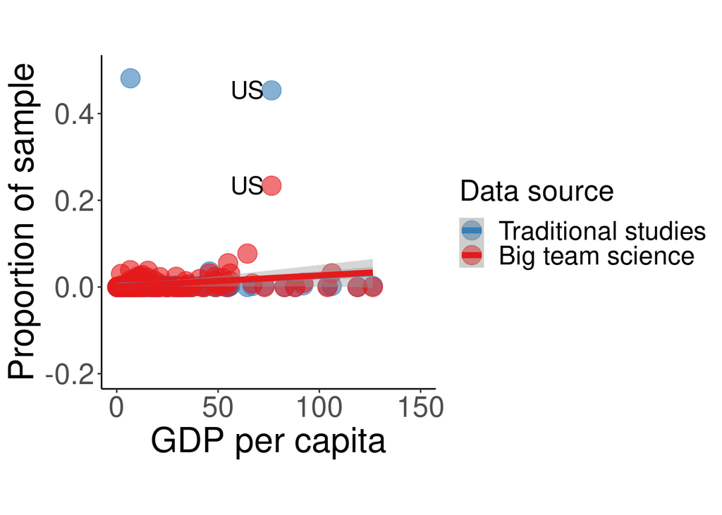

```r
combined_data2 <- rbind(
  transform(gdpdata, source = "PS2014", value = ps2014),
  transform(gdpdata, source = "PSA001", value = percentage_sample)
)
# Create the plot
gdp1 <- ggplot(combined_data2, aes(x = GDP_per_capita, y = value, color = source)) +

 geom_point(size = 6, alpha = 0.6) +
  geom_smooth(method ="lm",size = 2) +
  scale_color_brewer(palette = 'Set1') +
 scale_color_manual(name = "Data source",
                    values = c("#377EB8","#E41A1C"),
                    labels = c("Traditional studies", "Big team science"))+

  ylab("Proportion of sample") +
  xlab("GDP per capita") +
  theme(axis.text = element_text(size = 20),
        axis.title = element_text(size = 24),
        panel.background = element_rect(fill = "white"),
        axis.line = element_line(color = "black"),
        aspect.ratio = 1,
        legend.position = "right",
        legend.text = element_text(size = 18),
        legend.title = element_text(size = 20)) +
  xlim(c(0, 150)) +
  ylim(c(-0.2, 0.5)) +
  guides(color = guide_legend(override.aes = list(linetype = c("solid", "dashed"))))
# Adding the label
gdp1 <- gdp1 +
  annotate("text", x = 64.3, y = 0.455,
           label = expression("US"), size = 6) +
  annotate("text", x = 64.3, y = 0.235,
           label = expression("US"), size = 6)
gdp1
```

```r
# Save the plot as a JPEG image
#ggsave(filename = "GDP.jpg", plot = gdp1, device = "jpg", width = 12, height = 12)
```

## R&D_investment drawing

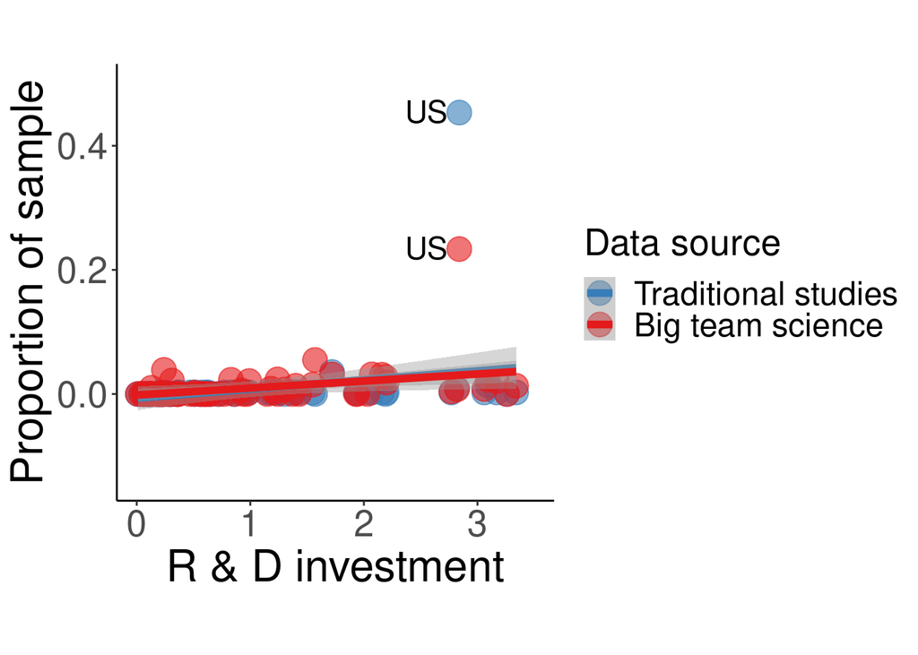

```r
combined_data3 <- rbind(
  transform(rddata, source = "PS2014", value = ps2014),
  transform(rddata, source = "PSA001", value = percentage_sample)
)
# Create the plot
RD1 <- ggplot(combined_data3, aes(x = R_D, y = value, color = source)) +

 geom_point(size = 6, alpha = 0.6) +
  geom_smooth(method ="lm",size = 2) +
  scale_color_brewer(palette = 'Set1') +
scale_color_manual(name = "Data source",
                    values = c("#377EB8","#E41A1C"),
                    labels = c("Traditional studies", "Big team science"))+
  ylab("Proportion of sample") +
  xlab("R & D investment") +
  theme(axis.text = element_text(size = 20),
        axis.title = element_text(size = 24),
        panel.background = element_rect(fill = "white"),
        axis.line = element_line(color = "black"),
        aspect.ratio = 1,
        legend.position = "right",
        legend.text = element_text(size = 18),
        legend.title = element_text(size = 20)) +
  xlim(c(0, 3.5)) +
  ylim(c(-0.14, 0.5)) +
  guides(color = guide_legend(override.aes = list(linetype = c("solid", "dashed"))))
# Adding the label
RD1 <- RD1 +
  annotate("text", x = 2.55, y = 0.455,
           label = expression("US"), size = 6) +
  annotate("text", x = 2.55, y = 0.235,
           label = expression("US"), size = 6)

# Print the plot
RD1
```

```r
# Save the plot as a JPEG image
#ggsave(filename = "RD.jpg", plot = RD1, device = "jpg", width = 12, height = 12)
```

## number_of_universities_per_capita drawing

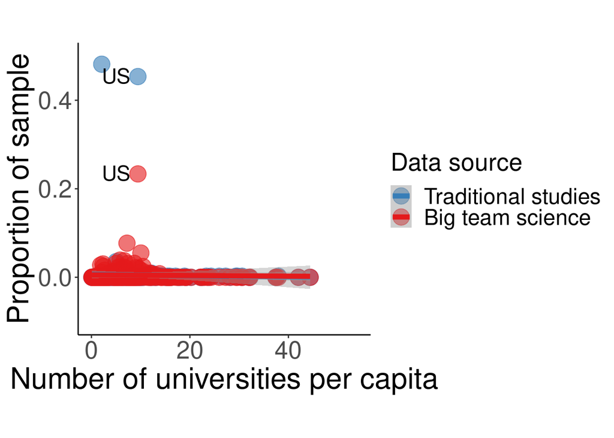

```r
combined_data1 <- rbind(
  transform(universitydata, source = "PS2014", value = ps2014),
  transform(universitydata, source = "PSA001", value = percentage_sample)
)
# Create the plot
university <- ggplot(combined_data1, aes(x = number_of_universities_per_capita, y = value, color = source)) +

 geom_point(size = 6, alpha = 0.6) +
  geom_smooth(method ="lm",size = 2) +
  scale_color_brewer(palette = 'Set1') +
 scale_color_manual(name = "Data source",
                    values = c("#377EB8","#E41A1C"),
                    labels = c("Traditional studies", "Big team science")) +

  ylab("Proportion of sample") +
  xlab("Number of universities per capita") +
  theme(axis.text = element_text(size = 20),
        axis.title = element_text(size = 24),
        panel.background = element_rect(fill = "white"),
        axis.line = element_line(color = "black"),
        aspect.ratio = 1,
        legend.position = "right",
        legend.text = element_text(size = 18),
        legend.title = element_text(size = 20)) +
  xlim(c(0, 54)) +
  ylim(c(-0.10, 0.5)) +
  guides(color = guide_legend(override.aes = list(linetype = c("solid", "dashed"))))
# Adding the label
university <- university +
  annotate("text", x = 5, y = 0.455,
           label = expression("US"), size = 6) +
  annotate("text", x = 5, y = 0.235,
           label = expression("US"), size = 6)
# Print the plot
university
```

```r
# Save the plot as a JPEG image
#ggsave(filename = "university.jpg", plot = university, device = "jpg", width = 12, height = 12)
```

## number_of_psychology_researchers_per_capita drawing

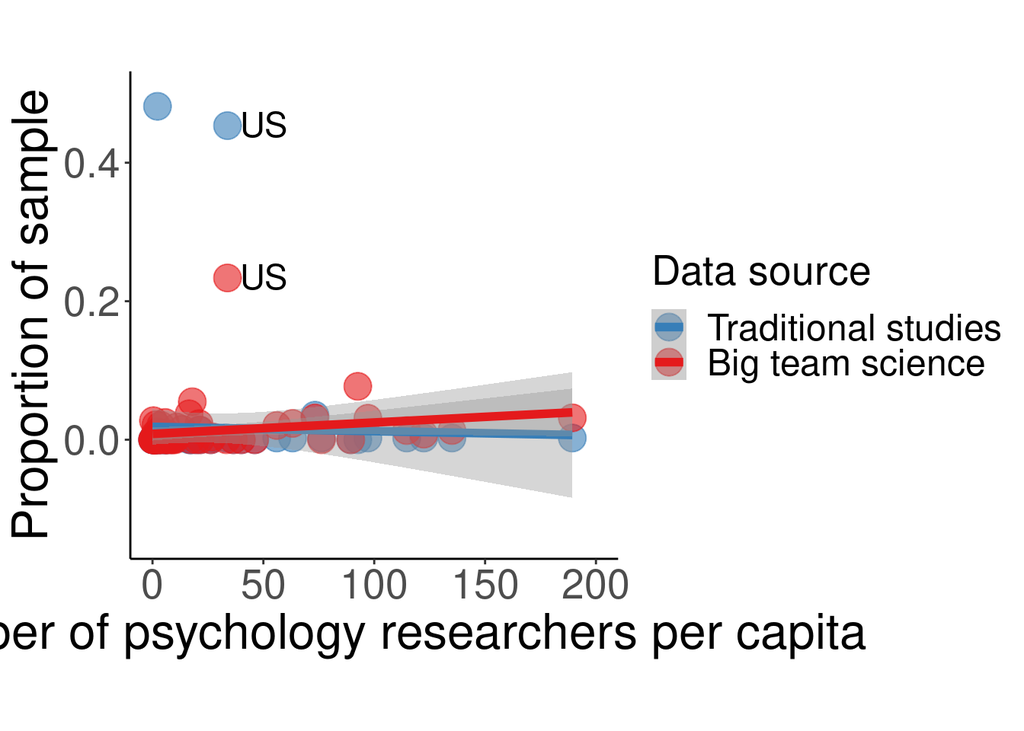

```r
combined_data1 <- rbind(
  transform(researcherdata, source = "PS2014", value = ps2014),
  transform(researcherdata, source = "PSA001", value = percentage_sample)
)
# Create the plot
researcher <- ggplot(combined_data1, aes(x = number_of_psychology_researchers_per_capita, y = value, color = source)) +

 geom_point(size = 6, alpha = 0.6) +
  geom_smooth(method ="lm",size = 2) +
  scale_color_brewer(palette = 'Set1') +
 scale_color_manual(name = "Data source",
                    values = c("#377EB8","#E41A1C"),
                    labels = c("Traditional studies", "Big team science")) +

  ylab("Proportion of sample") +
  xlab("Number of psychology researchers per capita") +
  theme(axis.text = element_text(size = 20),
        axis.title = element_text(size = 24),
        panel.background = element_rect(fill = "white"),
        axis.line = element_line(color = "black"),
        aspect.ratio = 1,
        legend.position = "right",
        legend.text = element_text(size = 18),
        legend.title = element_text(size = 20)) +
  xlim(c(0, 200)) +
  ylim(c(-0.14, 0.5)) +
  guides(color = guide_legend(override.aes = list(linetype = c("solid", "dashed"))))
# Adding the label
researcher <- researcher +
  annotate("text", x = 50, y = 0.455,
           label = expression("US"), size = 6) +
  annotate("text", x = 50, y = 0.235,
           label = expression("US"), size = 6)
# Print the plot
researcher
```

```r
# Save the plot as a JPEG image
ggsave(filename = "researcher.jpg", plot = researcher, device = "jpg", width = 12, height = 12)
```

## average_years_of_schooling drawing

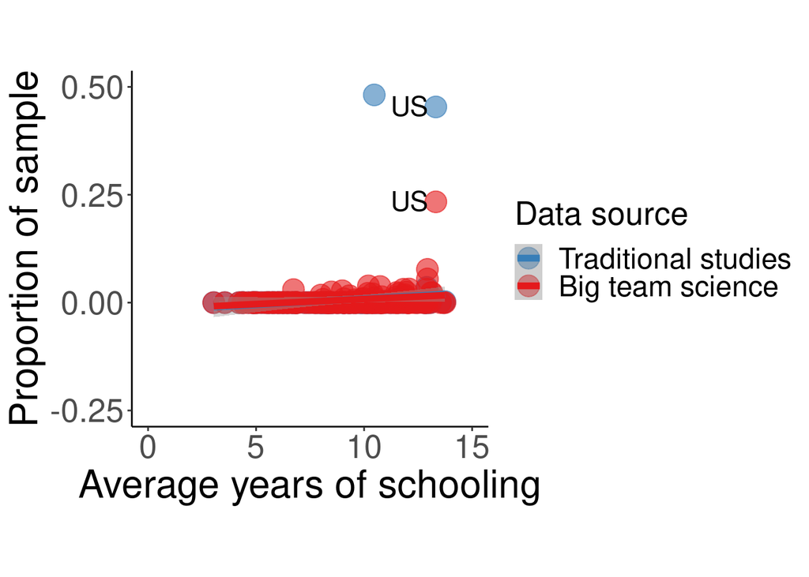

```r
combined_data9 <- rbind(
  transform(edudata, source = "PS2014", value = ps2014),
  transform(edudata, source = "PSA001", value = percentage_sample)
)
# Create the plot
education1 <- ggplot(combined_data9, aes(x = average_years_of_schooling, y = value, color = source)) +

 geom_point(size = 6, alpha = 0.6) +
  geom_smooth(method ="lm",size = 2) +
  scale_color_brewer(palette = 'Set1') +
 scale_color_manual(name = "Data source",
                    values = c("#377EB8","#E41A1C"),
                    labels = c("Traditional studies", "Big team science"))+

  ylab("Proportion of sample") +
  xlab("Average years of schooling") +
  theme(axis.text = element_text(size = 20),
        axis.title = element_text(size = 24),
        panel.background = element_rect(fill = "white"),
        axis.line = element_line(color = "black"),
        aspect.ratio = 1,
        legend.position = "right",
        legend.text = element_text(size = 18),
        legend.title = element_text(size = 20)) +
  xlim(c(0, 15)) +
  ylim(c(-0.25, 0.5)) +
  guides(color = guide_legend(override.aes = list(linetype = c("solid", "dashed"))))
# Adding the annotations
education1 <- education1 +
  annotate("text", x = 12.1, y = 0.455,
           label = expression("US"), size = 6) +
  annotate("text", x = 12.1, y = 0.235,
           label = expression("US"), size = 6)

# Print the plot
education1
```

```r
# Save the plot as a JPEG image
#ggsave(filename = "education.jpg", plot = education1, device = "jpg", width = 12, height = 12)
```

## Urbanization drawing

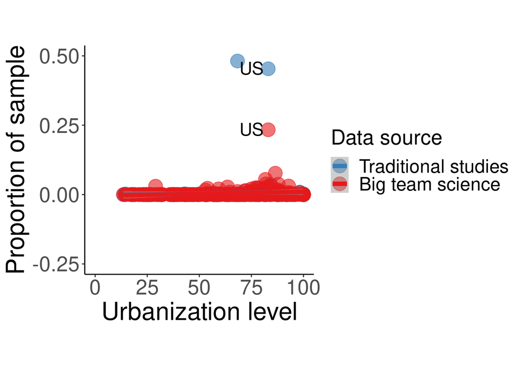

```r
combined_data8 <- rbind(
  transform(urbandata, source = "PS2014", value = ps2014),
  transform(urbandata, source = "PSA001", value = percentage_sample)
)
# Create the plot
UP1 <- ggplot(combined_data8, aes(x = Urbanization, y = value, color = source)) +

 geom_point(size = 6, alpha = 0.6) +
  geom_smooth(method ="lm",size = 2) +
  scale_color_brewer(palette = 'Set1') +
 scale_color_manual(name = "Data source",
                    values = c("#377EB8","#E41A1C"),
                    labels = c("Traditional studies", "Big team science"))+

  ylab("Proportion of sample") +
  xlab("Urbanization level") +
  theme(axis.text = element_text(size = 20),
        axis.title = element_text(size = 24),
        panel.background = element_rect(fill = "white"),
        axis.line = element_line(color = "black"),
        aspect.ratio = 1,
        legend.position = "right",
        legend.text = element_text(size = 18),
        legend.title = element_text(size = 20)) +
  xlim(c(0, 100)) +
  ylim(c(-0.25, 0.5)) +
  guides(color = guide_legend(override.aes = list(linetype = c("solid", "dashed"))))
# Adding the annotations
UP1 <- UP1 +
  annotate("text", x = 75, y = 0.455,
           label = expression("US"), size = 6) +
  annotate("text", x = 75, y = 0.235,
           label = expression("US"), size = 6)

# Print the plot
UP1
```

```r
# Save the plot as a JPEG image
#ggsave(filename = "UP.jpg", plot = UP1, device = "jpg", width = 12, height = 12)
```

## Globalization_Index drawing

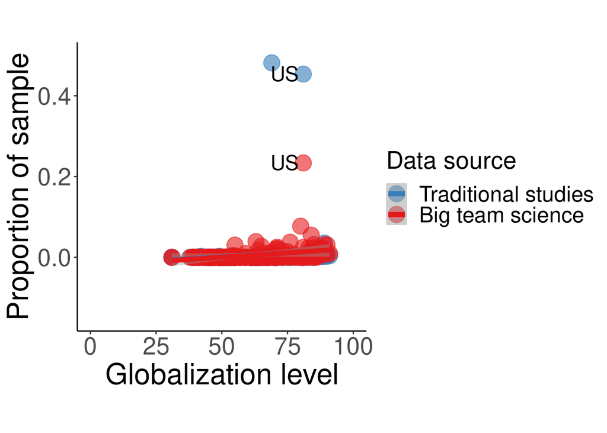

```r
combined_data4 <- rbind(
  transform(gidata, source = "PS2014", value = ps2014),
  transform(gidata, source = "PSA001", value = percentage_sample)
)
# Create the plot
GI1 <- ggplot(combined_data4, aes(x = GI, y = value, color = source)) +
 geom_point(size = 6, alpha = 0.6) +
  geom_smooth(method ="lm",size = 2) +
  scale_color_brewer(palette = 'Set1') +
 scale_color_manual(name = "Data source",
                    values = c("#377EB8","#E41A1C"),
                    labels = c("Traditional studies", "Big team science"))+
  ylab("Proportion of sample") +
  xlab("Globalization level") +
  theme(axis.text = element_text(size = 20),
        axis.title = element_text(size = 24),
        panel.background = element_rect(fill = "white"),
        axis.line = element_line(color = "black"),
        aspect.ratio = 1,
        legend.position = "right",
        legend.text = element_text(size = 18),
        legend.title = element_text(size = 20)) +
  xlim(c(0, 100)) +
  ylim(c(-0.15, 0.5)) +
  guides(color = guide_legend(override.aes = list(linetype = c("solid", "dashed"))))
# Adding the annotations
GI1 <- GI1 +
  annotate("text", x = 73.8, y = 0.455,
           label = expression("US"), size = 6) +
  annotate("text", x = 73.8, y = 0.235,
           label = expression("US"), size = 6)
# Print the plot
GI1
```

```r
# Save the plot as a JPEG image
#ggsave(filename = "GI.jpg", plot = GI1, device = "jpg", width = 12, height = 12)
```

## Internet penetration rate drawing

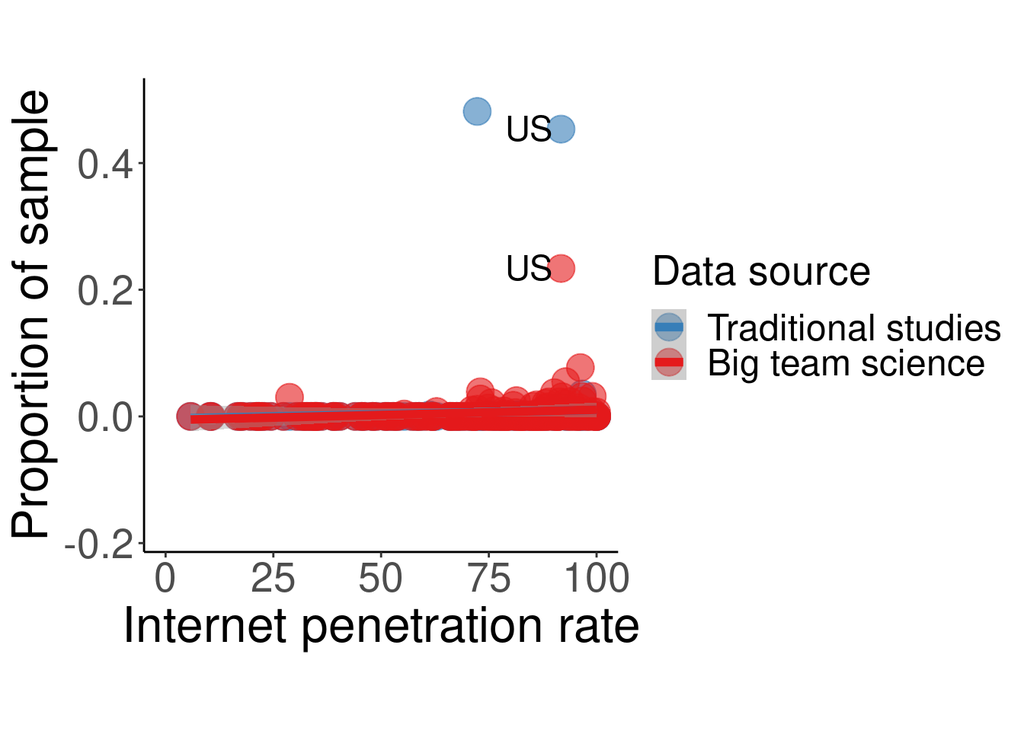

```r
combined_data5 <- rbind(
  transform(networkdata, source = "PS2014", value = ps2014),
  transform(networkdata, source = "PSA001", value = percentage_sample)
)
# Create the plot
Network1 <- ggplot(combined_data5, aes(x = Network_2021, y = value, color = source)) +

 geom_point(size = 6, alpha = 0.6) +
  geom_smooth(method ="lm",size = 2) +
  scale_color_brewer(palette = 'Set1') +
 scale_color_manual(name = "Data source",
                    values = c("#377EB8","#E41A1C"),
                    labels = c("Traditional studies", "Big team science"))+

  ylab("Proportion of sample") +
  xlab("Internet penetration rate") +
  theme(axis.text = element_text(size = 20),
        axis.title = element_text(size = 24),
        panel.background = element_rect(fill = "white"),
        axis.line = element_line(color = "black"),
        aspect.ratio = 1,
        legend.position = "right",
        legend.text = element_text(size = 18),
        legend.title = element_text(size = 20)) +
  xlim(c(0, 100)) +
  ylim(c(-0.18, 0.5)) +
  guides(color = guide_legend(override.aes = list(linetype = c("solid", "dashed"))))
# Adding the annotations
Network1 <- Network1 +
  annotate("text", x = 84.3, y = 0.455,
           label = expression("US"), size = 6) +
  annotate("text", x = 84.3, y = 0.235,
           label = expression("US"), size = 6)

Network1
```

```r
# Save the plot as a JPEG image
# ggsave(filename = "Network.jpg", plot = Network1, device = "jpg", width = 12, height = 12)
```

## cultural distance drawing

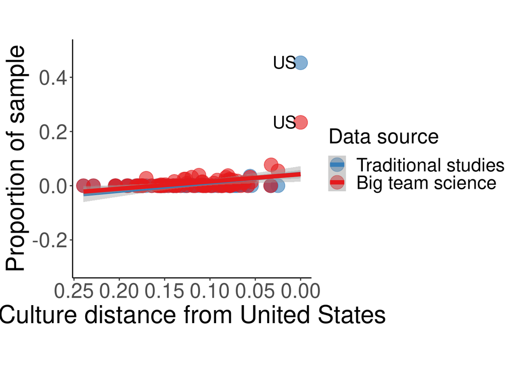

```r
combined_data1 <- rbind(
  transform(pddata, source = "PS2014", value = ps2014),
  transform(pddata, source = "PSA001", value = percentage_sample)
)
# Create the plot
pd1 <- ggplot(combined_data1, aes(x = pd, y = value, color = source)) +

 geom_point(size = 6, alpha = 0.6) +
  geom_smooth(method ="lm",size = 2) +
  scale_color_brewer(palette = 'Set1') +
 scale_color_manual(name = "Data source",
                    values = c("#377EB8","#E41A1C"),
                    labels = c("Traditional studies", "Big team science")) +

  ylab("Proportion of sample") +
  xlab("Culture distance from United States") +
  theme(axis.text = element_text(size = 20),
        axis.title = element_text(size = 24),
        panel.background = element_rect(fill = "white"),
        axis.line = element_line(color = "black"),
        aspect.ratio = 1,
        legend.position = "right",
        legend.text = element_text(size = 18),
        legend.title = element_text(size = 20)) +
  xlim(c(0, 0.20)) +
  ylim(c(-0.30, 0.5)) +
  guides(color = guide_legend(override.aes = list(linetype = c("solid", "dashed"))))
# Adding the label
pd1 <- pd1 +
  annotate("text", x = 0.018, y = 0.455,
           label = expression("US"), size = 6) +
  annotate("text", x = 0.018, y = 0.235,
           label = expression("US"), size = 6)
#turn over X-axis
pd1 <- pd1 + scale_x_reverse()
# Print the plot
pd1
```

```r
# Save the plot as a JPEG image
# ggsave(filename = "PD.jpg", plot = pd1, device = "jpg", width = 12, height = 12)
```

## Linguistic_distance_1 drawing

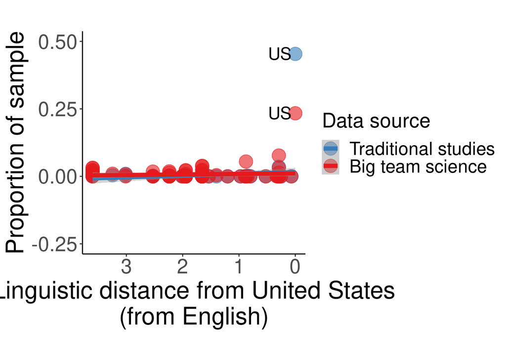

```r
combined_data6 <- rbind(
  transform(lddata, source = "PS2014", value = ps2014),
  transform(lddata, source = "PSA001", value = percentage_sample)
)
# Create the plot
ld1 <- ggplot(combined_data6, aes(x = lp1, y = value, color = source)) +

 geom_point(size = 6, alpha = 0.6) +
  geom_smooth(method ="lm",size = 2) +
  scale_color_brewer(palette = 'Set1') +
scale_color_manual(name = "Data source",
                    values = c("#377EB8","#E41A1C"),
                    labels = c("Traditional studies", "Big team science"))+
  ylab("Proportion of sample") +
  xlab("Linguistic distance from United States\n(from English)") +
  theme(axis.text = element_text(size = 20),
        axis.title = element_text(size = 24),
        panel.background = element_rect(fill = "white"),
        axis.line = element_line(color = "black"),
        aspect.ratio = 1,
        legend.position = "right",
        legend.text = element_text(size = 18),
        legend.title = element_text(size = 20)) +
  xlim(c(0, 3.5)) +
  ylim(c(-0.25, 0.5)) +
  guides(color = guide_legend(override.aes = list(linetype = c("solid", "dashed"))))
# Adding the label
ld1 <- ld1 +
  annotate("text", x = 0.28, y = 0.455,
           label = expression("US"), size = 6) +
  annotate("text", x = 0.28, y = 0.235,
           label = expression("US"), size = 6)

# turn over X-axis
ld1 <- ld1 + scale_x_reverse()
# Print the plot
ld1
```

```r
# Save the plot as a JPEG image
#ggsave(filename = "LD.jpg", plot = ld1, device = "jpg", width = 12, height = 12)
```

## English Proficiency Index rank drawing

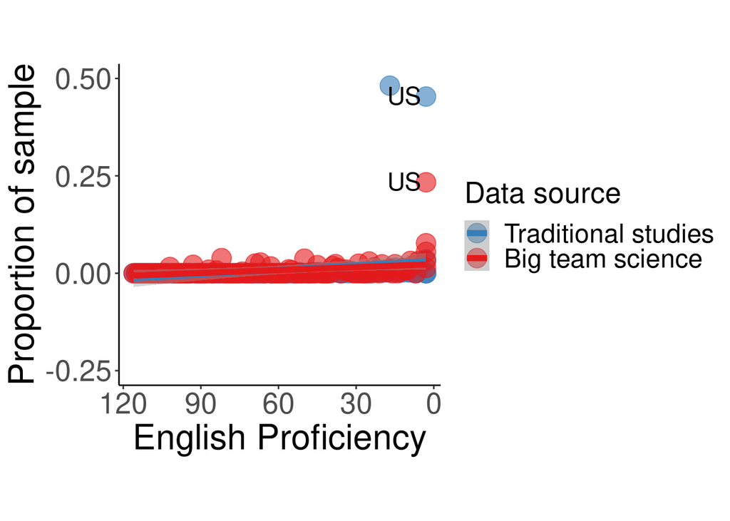

```r
combined_data7 <- rbind(
  transform(englishdata, source = "PS2014", value = ps2014),
  transform(englishdata, source = "PSA001", value = percentage_sample)
)
# Create the plot
EPI1 <- ggplot(combined_data7, aes(x = EPI_rank, y = value, color = source)) +

 geom_point(size = 6, alpha = 0.6) +
  geom_smooth(method ="lm",size = 2) +
  scale_color_brewer(palette = 'Set1') +
 scale_color_manual(name = "Data source",
                    values = c("#377EB8","#E41A1C"),
                    labels = c("Traditional studies", "Big team science"))+

  ylab("Proportion of sample") +
  xlab("English Proficiency") +
  theme(axis.text = element_text(size = 20),
        axis.title = element_text(size = 24),
        panel.background = element_rect(fill = "white"),
        axis.line = element_line(color = "black"),
        aspect.ratio = 1,
        legend.position = "right",  # 设置图例位置为顶部
        legend.text = element_text(size = 18),  # 设置图例文本字体大小
        legend.title = element_text(size = 20)) +
  xlim(c(0, 120)) +
  ylim(c(-0.25, 0.5)) +
  guides(color = guide_legend(override.aes = list(linetype = c("solid", "dashed"))))
# Adding the annotations
EPI1 <- EPI1 +
  annotate("text", x = 11.5, y = 0.455,
           label = expression("US"), size = 6) +
  annotate("text", x = 11.5, y = 0.235,
           label = expression("US"), size = 6)

# turn over X-axis
EPI1 <- EPI1 + scale_x_reverse()
# Print the plot
EPI1
```

```r
# Save the plot as a JPEG image
# ggsave(filename = "EPI.jpg", plot = EPI1, device = "jpg", width = 12, height = 12)
```

Merge the figures

```r
# Arrange 11 graphics horizontally, left and right
combined_plot1 <- gdp1+ RD1+university+  researcher+education1+UP1+GI1+ Network1 + pd1+ld1+EPI1 +
  patchwork::plot_layout(ncol = 3) +
patchwork::plot_annotation(tag_levels ="A",
                  theme = theme(plot.title = element_text(size = 26)))

# Save the plot as a PDF image
ggsave(filename = "Exploratory_analyses.pdf", plot = combined_plot1, device = "pdf", width = 24, height = 20)
```

# State/Province level

Relation between the proportion of each state’s/province’s sample in big team science (using Ruggeri et al. (2022) as an example) and Urbanization/Internet penetration rate/English Proficiency in Kenya/Nigeria, China, and United States/Netherlands.

## Urbanization

### KE_urbanization

```r
KE_urbanization <- read_csv("KE_urbanization.csv")
KE_urbanization
```

```
## # A tibble: 8 × 7
##   Province      `urban populaition` population KE_UP_2020 Ruggeri_KE total_KE
##   <chr>                       <dbl>      <dbl>      <dbl>      <dbl>    <dbl>
## 1 Central                   2177847   5481849.      0.397          5      120
## 2 Coast                     1939583   4327983.      0.448          7      120
## 3 Eastern                   1025466   6809051.      0.151          2      120
## 4 Nairobi                   4395749   4395749       1             90      120
## 5 North Eastern              658442   2487235.      0.265          1      120
## 6 Nyanza                    1008284   6259751.      0.161          7      120
## 7 Rift Valley               3082533  12751056.      0.242          5      120
## 8 Western                    547521   5024584.      0.109          3      120
## # ℹ 1 more variable: Ruggeri_KE_pro <dbl>
```

```r
KE_urbanization_model_beta_zi <- brms::brm(
  bf(Ruggeri_KE| trials(total_KE) ~ KE_UP_2020,
     phi ~ KE_UP_2020,
     zi ~ KE_UP_2020),
  data = KE_urbanization,
  family = zero_inflated_beta_binomial(),
  chains = 4, iter = 2000, warmup = 1000,
  cores = 2, seed = 1234,

  backend = "cmdstanr",
  file = "KE_urbanization_model_beta_zi "
)
tidy(KE_urbanization_model_beta_zi, effects = "fixed")
```

```
## # A tibble: 6 × 7
##   effect component term            estimate std.error conf.low conf.high
##   <chr>  <chr>     <chr>              <dbl>     <dbl>    <dbl>     <dbl>
## 1 fixed  cond      (Intercept)       -4.10      0.496  -4.76       -3.60
## 2 fixed  cond      phi_(Intercept)    7.83     14.9    -2.52       33.5
## 3 fixed  zi        (Intercept)       -0.183     1.13   -1.69        1.17
## 4 fixed  cond      KE_UP_2020         3.19      2.39   -0.0234      6.14
## 5 fixed  cond      phi_KE_UP_2020    55.5      22.8    40.5        95.7
## 6 fixed  zi        KE_UP_2020        -9.42      7.54  -18.6         1.89
```

```r
ame_beta_zi_KE_urbanization <- KE_urbanization_model_beta_zi %>%
  marginaleffects::avg_comparisons(variables = "KE_UP_2020") %>%
  marginaleffects::posterior_draws()
ame_beta_zi_KE_urbanization %>% tidybayes::median_hdi(draw)
```

```
## # A tibble: 2 × 6
##    draw .lower .upper .width .point .interval
##   <dbl>  <dbl>  <dbl>  <dbl> <chr>  <chr>
## 1  21.5   2.36   2.79   0.95 median hdi
## 2  21.5  43.5   45.0    0.95 median hdi
```

```r
result <- brms::hypothesis(ame_beta_zi_KE_urbanization, "draw>0")
result
```

```
## Hypothesis Tests for class :
##   Hypothesis Estimate Est.Error CI.Lower CI.Upper Evid.Ratio Post.Prob Star
## 1 (draw) > 0    22.66     15.87     2.43    45.02        Inf         1    *
## ---
## 'CI': 90%-CI for one-sided and 95%-CI for two-sided hypotheses.
## '*': For one-sided hypotheses, the posterior probability exceeds 95%;
## for two-sided hypotheses, the value tested against lies outside the 95%-CI.
## Posterior probabilities of point hypotheses assume equal prior probabilities.
```

### CN_urbanization

```r
CN_urbanization <- read_csv("CN_urbanization.csv")
CN_urbanization
```

```
## # A tibble: 31 × 5
##    State     CN_UP_2020 Ruggeri_CN total_CN Ruggeri_CN_pro
##    <chr>          <dbl>      <dbl>    <dbl>          <dbl>
##  1 Guizhou        0.532          1      387        0.00258
##  2 Hainan         0.603          1      387        0.00258
##  3 Jiangxi        0.604          1      387        0.00258
##  4 Shaanxi        0.627          1      387        0.00258
##  5 Tianjin        0.847          1      387        0.00258
##  6 Anhui          0.583          2      387        0.00517
##  7 Chongqing      0.695          2      387        0.00517
##  8 Hebei          0.601          2      387        0.00517
##  9 Yunnan         0.500          2      387        0.00517
## 10 Fujian         0.688          3      387        0.00775
## # ℹ 21 more rows
```

```r
CN_urbanization_model_beta_zi <- brms::brm(
  bf(Ruggeri_CN| trials(total_CN) ~ CN_UP_2020,
     phi ~ CN_UP_2020,
     zi ~ CN_UP_2020),
  data = CN_urbanization,
  family = zero_inflated_beta_binomial(),
  chains = 4, iter = 2000, warmup = 1000,
  cores = 2, seed = 1234,

  backend = "cmdstanr",
  file = "CN_urbanization_model_beta_zi "
)
tidy(CN_urbanization_model_beta_zi, effects = "fixed")
```

```
## # A tibble: 6 × 7
##   effect component term             estimate std.error   conf.low conf.high
##   <chr>  <chr>     <chr>               <dbl>     <dbl>      <dbl>     <dbl>
## 1 fixed  cond      (Intercept)        -2.31      1.41      -3.95     0.0364
## 2 fixed  cond      phi_(Intercept)     0.689     1.43      -1.22     3.38
## 3 fixed  zi        (Intercept)     -5954.     7862.    -25820.       0.666
## 4 fixed  cond      CN_UP_2020          0.120     0.354     -0.865    0.578
## 5 fixed  cond      phi_CN_UP_2020      0.568     1.14      -1.91     3.40
## 6 fixed  zi        CN_UP_2020       2133.     2815.        -0.140 9248.
```

```r
ame_beta_zi_CN_urbanization <- CN_urbanization_model_beta_zi %>%
  marginaleffects::avg_comparisons(variables = "CN_UP_2020") %>%
  marginaleffects::posterior_draws()
ame_beta_zi_CN_urbanization %>% tidybayes::median_hdi(draw)
```

```
## # A tibble: 13 × 6
##     draw .lower .upper .width .point .interval
##    <dbl>  <dbl>  <dbl>  <dbl> <chr>  <chr>
##  1  6.93  -17.9  -17.9   0.95 median hdi
##  2  6.93  -15.9  -14.9   0.95 median hdi
##  3  6.93  -14.7  -14.6   0.95 median hdi
##  4  6.93  -14.4  -13.5   0.95 median hdi
##  5  6.93  -13.2  -13.2   0.95 median hdi
##  6  6.93  -12.9  -12.6   0.95 median hdi
##  7  6.93  -12.0  -11.3   0.95 median hdi
##  8  6.93  -11.1   12.5   0.95 median hdi
##  9  6.93   12.9   13.3   0.95 median hdi
## 10  6.93   14.1   14.8   0.95 median hdi
## 11  6.93   15.7   16.3   0.95 median hdi
## 12  6.93   17.6   17.9   0.95 median hdi
## 13  6.93   20.7   20.9   0.95 median hdi
```

```r
result <- brms::hypothesis(ame_beta_zi_CN_urbanization, "draw>0")
result
```

```
## Hypothesis Tests for class :
##   Hypothesis Estimate Est.Error CI.Lower CI.Upper Evid.Ratio Post.Prob Star
## 1 (draw) > 0     4.17      6.32    -8.37     8.99       4.96      0.83
## ---
## 'CI': 90%-CI for one-sided and 95%-CI for two-sided hypotheses.
## '*': For one-sided hypotheses, the posterior probability exceeds 95%;
## for two-sided hypotheses, the value tested against lies outside the 95%-CI.
## Posterior probabilities of point hypotheses assume equal prior probabilities.
```

### US_urbanization

```r
US_urbanization <- read_csv("US_urbanization.csv")
US_urbanization
```

```
## # A tibble: 51 × 5
##    state                US_UP_2020 Ruggeri_US total_US Ruggeri_US_pro
##    <chr>                     <dbl>      <dbl>    <dbl>          <dbl>
##  1 Alabama                   0.577          5      369        0.0136
##  2 Alaska                    0.649          1      369        0.00271
##  3 Arizona                   0.893          4      369        0.0108
##  4 Arkansas                  0.555          0      369        0
##  5 California                0.942         14      369        0.0379
##  6 Colorado                  0.86           5      369        0.0136
##  7 Connecticut               0.863          2      369        0.00542
##  8 Delaware                  0.826          0      369        0
##  9 District of Columbia      1             61      369        0.165
## 10 Florida                   0.915         41      369        0.111
## # ℹ 41 more rows
```

```r
US_urbanization_model_beta_zi <- brms::brm(
  bf(Ruggeri_US| trials(total_US) ~ US_UP_2020,
   phi ~ US_UP_2020,
     zi ~ US_UP_2020),
  data = US_urbanization,
  family = zero_inflated_beta_binomial(),
  chains = 4, iter = 2000, warmup = 1000,
  cores = 4, seed = 1234,

  backend = "cmdstanr",
  file = "US_urbanization_model_beta_zi "
)
tidy(US_urbanization_model_beta_zi, effects = "fixed")
```

```
## # A tibble: 6 × 7
##   effect component term            estimate std.error conf.low conf.high
##   <chr>  <chr>     <chr>              <dbl>     <dbl>    <dbl>     <dbl>
## 1 fixed  cond      (Intercept)       -6.13       1.20   -8.51      -3.84
## 2 fixed  cond      phi_(Intercept)    3.59       1.06    1.35       5.50
## 3 fixed  zi        (Intercept)       -6.41       5.97  -20.5        3.31
## 4 fixed  cond      US_UP_2020         3.07       1.53    0.132      6.02
## 5 fixed  cond      phi_US_UP_2020    -0.467      1.36   -3.03       2.31
## 6 fixed  zi        US_UP_2020         4.14       7.49  -10.0       19.7
```

```r
ame_beta_zi_US_urbanization <- US_urbanization_model_beta_zi %>%
  marginaleffects::avg_comparisons(variables = "US_UP_2020") %>%
  marginaleffects::posterior_draws()
ame_beta_zi_US_urbanization %>% tidybayes::median_hdi(draw)
```

```
## # A tibble: 2 × 6
##    draw .lower .upper .width .point .interval
##   <dbl>  <dbl>  <dbl>  <dbl> <chr>  <chr>
## 1  13.9  -6.65   63.9   0.95 median hdi
## 2  13.9  68.8    71.3   0.95 median hdi
```

```r
result <- brms::hypothesis(ame_beta_zi_US_urbanization, "draw>0")
result
```

```
## Hypothesis Tests for class :
##   Hypothesis Estimate Est.Error CI.Lower CI.Upper Evid.Ratio Post.Prob Star
## 1 (draw) > 0    19.85     20.83    -1.06    63.29      11.54      0.92
## ---
## 'CI': 90%-CI for one-sided and 95%-CI for two-sided hypotheses.
## '*': For one-sided hypotheses, the posterior probability exceeds 95%;
## for two-sided hypotheses, the value tested against lies outside the 95%-CI.
## Posterior probabilities of point hypotheses assume equal prior probabilities.
```

## Internet penetration rate

### NG_internet

```r
NG_internet <- read_csv("NG_internet.csv")
NG_internet
```

```
## # A tibble: 37 × 8
##    Orders State   `Active Internet 2022` Internet_NG_2022 percentage_Internet_…¹
##     <dbl> <chr>                    <dbl>            <dbl>                  <dbl>
##  1     20 Akwa I…               2702281             0.565                   20.9
##  2     36 Bayelsa               1096051.            0.458                   16.9
##  3     12 Benue                 3709942.            0.641                   23.7
##  4     26 Cross …               2021284             0.484                   17.9
##  5     16 Delta                 5453929.            1.03                    37.9
##  6     22 Edo                   5366544.            1.20                    44.4
##  7     31 Ekiti                 1407720.            0.420                   15.5
##  8     24 Enugu                 3032204.            0.690                   25.5
##  9     37 Federa…               7320230             2.71                   100
## 10      1 Kano                  8634113             0.606                   22.4
## # ℹ 27 more rows
## # ℹ abbreviated name: ¹percentage_Internet_NG_2022
## # ℹ 3 more variables: Ruggeri_NG <dbl>, total_NG <dbl>, Ruggeri_NG_pro <dbl>
```

```r
NG_internet_model_beta_zi <- brms::brm(
  bf(Ruggeri_NG| trials(total_NG) ~ Internet_NG_2022,
     phi ~ Internet_NG_2022,
     zi ~ Internet_NG_2022),
  data = NG_internet,
  family = zero_inflated_beta_binomial(),
  chains = 4, iter = 2000, warmup = 1000,
  cores = 2, seed = 1234,

  backend = "cmdstanr",
  file = "NG_internet_model_beta_zi "
)
tidy(NG_internet_model_beta_zi, effects = "fixed")
```

```
## # A tibble: 6 × 7
##   effect component term                 estimate std.error conf.low conf.high
##   <chr>  <chr>     <chr>                   <dbl>     <dbl>    <dbl>     <dbl>
## 1 fixed  cond      (Intercept)            -1.65       1.23    -4.52     0.464
## 2 fixed  cond      phi_(Intercept)        -1.19       1.79    -4.25     2.83
## 3 fixed  zi        (Intercept)            -2.07       3.08    -8.97     3.37
## 4 fixed  cond      Internet_NG_2022       -1.97       1.50    -4.33     1.78
## 5 fixed  cond      phi_Internet_NG_2022    3.58       2.44    -2.06     7.57
## 6 fixed  zi        Internet_NG_2022       -0.932      3.81    -9.79     5.62
```

```r
ame_beta_zi_NG_internet <- NG_internet_model_beta_zi %>%
  marginaleffects::avg_comparisons(variables = "Internet_NG_2022") %>%
  marginaleffects::posterior_draws()
ame_beta_zi_NG_internet %>% tidybayes::median_hdi(draw)
```

```
## # A tibble: 1 × 6
##    draw .lower .upper .width .point .interval
##   <dbl>  <dbl>  <dbl>  <dbl> <chr>  <chr>
## 1 -17.8  -79.7   23.5   0.95 median hdi
```

```r
result <- brms::hypothesis(ame_beta_zi_NG_internet, "draw<0")
result
```

```
## Hypothesis Tests for class :
##   Hypothesis Estimate Est.Error CI.Lower CI.Upper Evid.Ratio Post.Prob Star
## 1 (draw) < 0    -22.9     25.68   -73.02    10.01        6.6      0.87
## ---
## 'CI': 90%-CI for one-sided and 95%-CI for two-sided hypotheses.
## '*': For one-sided hypotheses, the posterior probability exceeds 95%;
## for two-sided hypotheses, the value tested against lies outside the 95%-CI.
## Posterior probabilities of point hypotheses assume equal prior probabilities.
```

### CN_internet

```r
CN_internet <- read_csv("CN_internet.csv")
CN_internet
```

```
## # A tibble: 31 × 5
##    State     Internet_CN_2016 Ruggeri_CN total_CN Ruggeri_CN_pro
##    <chr>                <dbl>      <dbl>    <dbl>          <dbl>
##  1 Guizhou              0.432          1      387        0.00258
##  2 Hainan               0.516          1      387        0.00258
##  3 Jiangxi              0.446          1      387        0.00258
##  4 Shaanxi              0.524          1      387        0.00258
##  5 Tianjin              0.646          1      387        0.00258
##  6 Anhui                0.443          2      387        0.00517
##  7 Chongqing            0.516          2      387        0.00517
##  8 Hebei                0.533          2      387        0.00517
##  9 Yunnan               0.399          2      387        0.00517
## 10 Fujian               0.697          3      387        0.00775
## # ℹ 21 more rows
```

```r
CN_internet_model_beta_zi <- brms::brm(
  bf(Ruggeri_CN| trials(total_CN) ~ Internet_CN_2016,
     phi ~ Internet_CN_2016,
     zi ~ Internet_CN_2016),
  data = CN_internet,
  family = zero_inflated_beta_binomial(),
  chains = 4, iter = 2000, warmup = 1000,
  cores = 2, seed = 1234,

  backend = "cmdstanr",
  file = "CN_internet_model_beta_zi "
)
tidy(CN_internet_model_beta_zi, effects = "fixed")
```

```
## # A tibble: 6 × 7
##   effect component term                 estimate std.error conf.low conf.high
##   <chr>  <chr>     <chr>                   <dbl>     <dbl>    <dbl>     <dbl>
## 1 fixed  cond      (Intercept)            -4.60       1.80    -8.18    -0.957
## 2 fixed  cond      phi_(Intercept)         1.96       2.16    -2.34     6.11
## 3 fixed  zi        (Intercept)            -0.917      6.02   -13.1     11.4
## 4 fixed  cond      Internet_CN_2016        2.64       3.12    -3.45     9.03
## 5 fixed  cond      phi_Internet_CN_2016   -0.191      3.80    -8.11     6.85
## 6 fixed  zi        Internet_CN_2016       -4.30      11.3    -31.1     15.0
```

```r
ame_beta_zi_CN_internet <- CN_internet_model_beta_zi %>%
  marginaleffects::avg_comparisons(variables = "Internet_CN_2016") %>%
  marginaleffects::posterior_draws()
ame_beta_zi_CN_internet %>% tidybayes::median_hdi(draw)
```

```
## # A tibble: 1 × 6
##    draw .lower .upper .width .point .interval
##   <dbl>  <dbl>  <dbl>  <dbl> <chr>  <chr>
## 1  34.2  -58.3   271.   0.95 median hdi
```

```r
result <- brms::hypothesis(ame_beta_zi_CN_internet, "draw>0")
result
```

```
## Hypothesis Tests for class :
##   Hypothesis Estimate Est.Error CI.Lower CI.Upper Evid.Ratio Post.Prob Star
## 1 (draw) > 0    56.92     80.69   -29.85   224.44       5.08      0.84
## ---
## 'CI': 90%-CI for one-sided and 95%-CI for two-sided hypotheses.
## '*': For one-sided hypotheses, the posterior probability exceeds 95%;
## for two-sided hypotheses, the value tested against lies outside the 95%-CI.
## Posterior probabilities of point hypotheses assume equal prior probabilities.
```

### US_internet

```r
US_internet <- read_csv("US_internet.csv")
US_internet
```

```
## # A tibble: 51 × 5
##    state        Internet_US_2018 Ruggeri_US total_US Ruggeri_US_pro
##    <chr>                   <dbl>      <dbl>    <dbl>          <dbl>
##  1 Arkansas                0.769          0      369              0
##  2 Delaware                0.884          0      369              0
##  3 Georgia                 0.837          0      369              0
##  4 Hawaii                  0.857          0      369              0
##  5 Louisiana               0.781          0      369              0
##  6 Montana                 0.836          0      369              0
##  7 Nevada                  0.859          0      369              0
##  8 North Dakota            0.803          0      369              0
##  9 Oregon                  0.879          0      369              0
## 10 South Dakota            0.821          0      369              0
## # ℹ 41 more rows
```

```r
US_internet_model_beta_zi <- brms::brm(
  bf(Ruggeri_US| trials(total_US) ~ Internet_US_2018,
     phi ~ Internet_US_2018,
     zi ~ Internet_US_2018),
  data = US_internet,
  family = zero_inflated_beta_binomial(),
  chains = 4, iter = 2000, warmup = 1000,
  cores = 2, seed = 1234,

  backend = "cmdstanr",
  file = "US_internet_model_beta_zi "
)
tidy(US_internet_model_beta_zi, effects = "fixed")
```

```
## # A tibble: 6 × 7
##   effect component term                 estimate std.error conf.low conf.high
##   <chr>  <chr>     <chr>                   <dbl>     <dbl>    <dbl>     <dbl>
## 1 fixed  cond      (Intercept)            -18.8       8.61   -34.4      -1.80
## 2 fixed  cond      phi_(Intercept)         18.6      15.2    -11.5      46.5
## 3 fixed  zi        (Intercept)             -1.41     28.3    -61.0      49.2
## 4 fixed  cond      Internet_US_2018        17.7      10.1     -2.36     36.3
## 5 fixed  cond      phi_Internet_US_2018   -18.1      17.8    -51.1      17.0
## 6 fixed  zi        Internet_US_2018        -2.60     33.3    -64.1      66.2
```

```r
ame_beta_zi_US_internet <- US_internet_model_beta_zi %>%
  marginaleffects::avg_comparisons(variables = "Internet_US_2018") %>%
  marginaleffects::posterior_draws()
ame_beta_zi_US_internet %>% tidybayes::median_hdi(draw)
```

```
## # A tibble: 5 × 6
##    draw .lower .upper .width .point .interval
##   <dbl>  <dbl>  <dbl>  <dbl> <chr>  <chr>
## 1  214.  -16.6   131.   0.95 median hdi
## 2  214.  143.    153.   0.95 median hdi
## 3  214.  181.    189.   0.95 median hdi
## 4  214.  209.    223.   0.95 median hdi
## 5  214.  239.    369.   0.95 median hdi
```

```r
result <- brms::hypothesis(ame_beta_zi_US_internet, "draw>0")
result
```

```
## Hypothesis Tests for class :
##   Hypothesis Estimate Est.Error CI.Lower CI.Upper Evid.Ratio Post.Prob Star
## 1 (draw) > 0    185.3    168.89     -0.2   368.98       5.59      0.85
## ---
## 'CI': 90%-CI for one-sided and 95%-CI for two-sided hypotheses.
## '*': For one-sided hypotheses, the posterior probability exceeds 95%;
## for two-sided hypotheses, the value tested against lies outside the 95%-CI.
## Posterior probabilities of point hypotheses assume equal prior probabilities.
```

## English Proficiency

### NG_EPI

```r
NG_EPI <- read_csv("NG_EPI.csv")
NG_EPI
```

```
## # A tibble: 37 × 8
##    Orders State      region score EPI_NG_2022 Ruggeri_NG total_NG Ruggeri_NG_pro
##     <dbl> <chr>      <chr>  <dbl>       <dbl>      <dbl>    <dbl>          <dbl>
##  1     31 Ekiti      South…   568           1          0      257              0
##  2     19 Ondo       South…   568           1          0      257              0
##  3     12 Benue      North…   564           7          0      257              0
##  4     27 Kogi       North…   564           7          0      257              0
##  5     33 Kwara      North…   564           7          0      257              0
##  6     20 Akwa Ibom  Niger…   560          14          0      257              0
##  7     36 Bayelsa    Niger…   560          14          0      257              0
##  8     26 Cross Riv… Niger…   560          14          0      257              0
##  9     16 Delta      Niger…   560          14          0      257              0
## 10     22 Edo        Niger…   560          14          0      257              0
## # ℹ 27 more rows
```

```r
NG_EPI_model_beta_zi <- brms::brm(
  bf(Ruggeri_NG| trials(total_NG) ~ EPI_NG_2022,
     phi ~ EPI_NG_2022,
     zi ~ EPI_NG_2022),
  data = NG_EPI,
  family = zero_inflated_beta_binomial(),
  chains = 4, iter = 2000, warmup = 1000,
  cores = 2, seed = 1234,

  backend = "cmdstanr",
  file = "NG_EPI_model_beta_zi "
)
tidy(NG_EPI_model_beta_zi, effects = "fixed")
```

```
## # A tibble: 6 × 7
##   effect component term            estimate std.error  conf.low conf.high
##   <chr>  <chr>     <chr>              <dbl>     <dbl>     <dbl>     <dbl>
## 1 fixed  cond      (Intercept)      -0.281      4.15   -3.93       6.82
## 2 fixed  cond      phi_(Intercept) -13.5       24.2   -55.4        1.75
## 3 fixed  zi        (Intercept)      -0.402      4.18   -7.10       6.18
## 4 fixed  cond      EPI_NG_2022      -0.150      0.200  -0.493      0.0255
## 5 fixed  cond      phi_EPI_NG_2022   0.864      1.39   -0.00940    3.26
## 6 fixed  zi        EPI_NG_2022      -0.0991     0.180  -0.378      0.167
```

```r
ame_beta_zi_NG_EPI <- NG_EPI_model_beta_zi %>%
  marginaleffects::avg_comparisons(variables = "EPI_NG_2022") %>%
  marginaleffects::posterior_draws()
ame_beta_zi_NG_EPI %>% tidybayes::median_hdi(draw)
```

```
## # A tibble: 3 × 6
##     draw .lower .upper .width .point .interval
##    <dbl>  <dbl>  <dbl>  <dbl> <chr>  <chr>
## 1 -0.143  -1.48 -1.44    0.95 median hdi
## 2 -0.143  -1.41 -1.40    0.95 median hdi
## 3 -0.143  -1.31  0.362   0.95 median hdi
```

```r
result <- brms::hypothesis(ame_beta_zi_NG_EPI, "draw<0")
result
```

```
## Hypothesis Tests for class :
##   Hypothesis Estimate Est.Error CI.Lower CI.Upper Evid.Ratio Post.Prob Star
## 1 (draw) < 0    -0.22      0.45    -1.06     0.19       1.71      0.63
## ---
## 'CI': 90%-CI for one-sided and 95%-CI for two-sided hypotheses.
## '*': For one-sided hypotheses, the posterior probability exceeds 95%;
## for two-sided hypotheses, the value tested against lies outside the 95%-CI.
## Posterior probabilities of point hypotheses assume equal prior probabilities.
```

### CN_EPI

```r
CN_EPI <- read_csv("CN_EPI.csv")
CN_EPI
```

```
## # A tibble: 31 × 6
##    State     score EPI_CN_2022 Ruggeri_CN total_CN Ruggeri_CN_pro
##    <chr>     <dbl>       <dbl>      <dbl>    <dbl>          <dbl>
##  1 Beijing     549           1          9      387        0.0233
##  2 Shanghai    549           1         65      387        0.168
##  3 Tianjin     528           3          1      387        0.00258
##  4 Zhejiang    509           4         85      387        0.220
##  5 Shandong    496           5          4      387        0.0103
##  6 Guangdong   492           6         15      387        0.0388
##  7 Hubei       489           7          5      387        0.0129
##  8 Jiangsu     488           8         15      387        0.0388
##  9 Shaanxi     485           9          1      387        0.00258
## 10 Fujian      483          10          3      387        0.00775
## # ℹ 21 more rows
```

```r
CN_EPI_model_beta_zi <- brms::brm(
  bf(Ruggeri_CN| trials(total_CN) ~ EPI_CN_2022,
     phi ~ EPI_CN_2022,
     zi ~ EPI_CN_2022),
  data = CN_EPI,
  family = zero_inflated_beta_binomial(),
  chains = 4, iter = 2000, warmup = 1000,
  cores = 2, seed = 1234,

  backend = "cmdstanr",
  file = "CN_EPI_model_beta_zi"
)
tidy(CN_EPI_model_beta_zi, effects = "fixed")
```

```
## # A tibble: 6 × 7
##   effect component term            estimate std.error conf.low conf.high
##   <chr>  <chr>     <chr>              <dbl>     <dbl>    <dbl>     <dbl>
## 1 fixed  cond      (Intercept)      -2.73      0.520    -3.75    -1.69
## 2 fixed  cond      phi_(Intercept)   2.42      0.616     1.11     3.53
## 3 fixed  zi        (Intercept)      -4.56      2.68    -11.1     -0.786
## 4 fixed  cond      EPI_CN_2022      -0.0295    0.0368   -0.100    0.0453
## 5 fixed  cond      phi_EPI_CN_2022  -0.0376    0.0372   -0.114    0.0328
## 6 fixed  zi        EPI_CN_2022       0.0777    0.139    -0.209    0.362
```

```r
ame_beta_zi_CN_EPI <- CN_EPI_model_beta_zi %>%
  marginaleffects::avg_comparisons(variables = "EPI_CN_2022") %>%
  marginaleffects::posterior_draws()
ame_beta_zi_CN_EPI %>% tidybayes::median_hdi(draw)
```

```
## # A tibble: 1 × 6
##     draw .lower .upper .width .point .interval
##    <dbl>  <dbl>  <dbl>  <dbl> <chr>  <chr>
## 1 -0.478  -1.73  0.567   0.95 median hdi
```

```r
result <- brms::hypothesis(ame_beta_zi_CN_EPI, "draw<0")
result
```

```
## Hypothesis Tests for class :
##   Hypothesis Estimate Est.Error CI.Lower CI.Upper Evid.Ratio Post.Prob Star
## 1 (draw) < 0    -0.49      0.56    -1.41     0.37       6.38      0.86
## ---
## 'CI': 90%-CI for one-sided and 95%-CI for two-sided hypotheses.
## '*': For one-sided hypotheses, the posterior probability exceeds 95%;
## for two-sided hypotheses, the value tested against lies outside the 95%-CI.
## Posterior probabilities of point hypotheses assume equal prior probabilities.
```

### NL_EPI

```r
NL_EPI <- read_csv("NL_EPI.csv")
NL_EPI
```

```
## # A tibble: 12 × 6
##    state         score EPI_NL_2022 Ruggeri_NL total_NL Ruggeri_NL_pro
##    <chr>         <dbl>       <dbl>      <dbl>    <dbl>          <dbl>
##  1 Friesland       662           7          0      120        0
##  2 Limburg         658           9          0      120        0
##  3 Flevoland       645          11          0      120        0
##  4 Zeeland         678           1          1      120        0.00833
##  5 Overijssel      663           6          2      120        0.0167
##  6 Drenthe         629          12          2      120        0.0167
##  7 North Holland   671           4          7      120        0.0583
##  8 Utrecht         676           2          8      120        0.0667
##  9 Gelderland      665           5          8      120        0.0667
## 10 South Holland   671           3         12      120        0.1
## 11 Groningen       648          10         14      120        0.117
## 12 North Brabant   660           8         66      120        0.55
```

```r
NL_EPI_model_beta_zi <- brms::brm(
  bf(Ruggeri_NL| trials(total_NL) ~ EPI_NL_2022,
     phi ~ EPI_NL_2022,
     zi ~ EPI_NL_2022),
  data = NL_EPI,
  family = zero_inflated_beta_binomial(),
  chains = 4, iter = 2000, warmup = 1000,
  cores = 2, seed = 1234,

  backend = "cmdstanr",
  file = "NL_EPI_model_beta_zi "
)
tidy(NL_EPI_model_beta_zi, effects = "fixed")
```

```
## # A tibble: 6 × 7
##   effect component term            estimate std.error conf.low conf.high
##   <chr>  <chr>     <chr>              <dbl>     <dbl>    <dbl>     <dbl>
## 1 fixed  cond      (Intercept)       -3.28      0.812   -4.62    -1.25
## 2 fixed  cond      phi_(Intercept)    4.66      1.89     0.705    8.40
## 3 fixed  zi        (Intercept)       -3.84      2.75   -10.2      0.492
## 4 fixed  cond      EPI_NL_2022        0.193     0.143   -0.123    0.450
## 5 fixed  cond      phi_EPI_NL_2022   -0.464     0.248   -0.955    0.0391
## 6 fixed  zi        EPI_NL_2022        0.225     0.385   -0.575    0.960
```

```r
ame_beta_zi_NL_EPI <- NL_EPI_model_beta_zi %>%
  marginaleffects::avg_comparisons(variables = "EPI_NL_2022") %>%
  marginaleffects::posterior_draws()
ame_beta_zi_NL_EPI %>% tidybayes::median_hdi(draw)
```

```
## # A tibble: 1 × 6
##    draw .lower .upper .width .point .interval
##   <dbl>  <dbl>  <dbl>  <dbl> <chr>  <chr>
## 1  1.02  -1.38   5.63   0.95 median hdi
```

```r
result <- brms::hypothesis(ame_beta_zi_NL_EPI, "draw>0")
result
```

```
## Hypothesis Tests for class :
##   Hypothesis Estimate Est.Error CI.Lower CI.Upper Evid.Ratio Post.Prob Star
## 1 (draw) > 0     1.35      1.78    -0.81     4.74       4.12       0.8
## ---
## 'CI': 90%-CI for one-sided and 95%-CI for two-sided hypotheses.
## '*': For one-sided hypotheses, the posterior probability exceeds 95%;
## for two-sided hypotheses, the value tested against lies outside the 95%-CI.
## Posterior probabilities of point hypotheses assume equal prior probabilities.
```

# State/Province level drawing

## Urbanization drawing by state/province in Kenya, China, and the United States

### Kenya drawing (Urbanization)

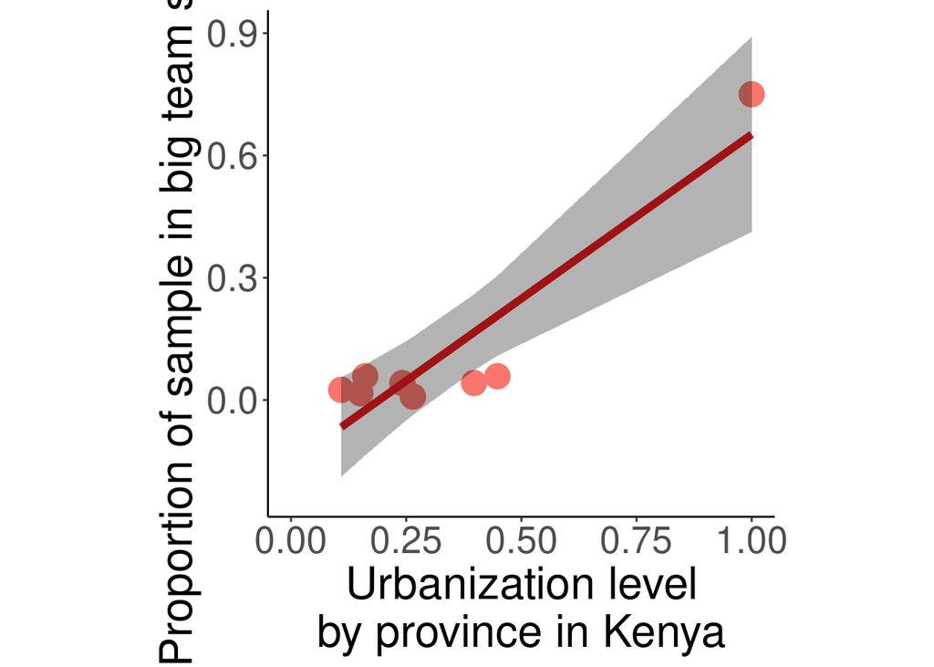

```r
model <- lm(Ruggeri_KE_pro ~ KE_UP_2020, data = KE_urbanization)
predict_data_KE <- data.frame(KE_UP_2020 = KE_urbanization$KE_UP_2020, Ruggeri_KE_pro = KE_urbanization$Ruggeri_KE_pro )
predict_data_KE$predicted <- predict(model, newdata = predict_data_KE)
predict_data_KE$lower <- predict(model, newdata = KE_urbanization, interval = "confidence")[, "lwr"]
predict_data_KE$upper <- predict(model, newdata = KE_urbanization, interval = "confidence")[, "upr"]

KE_UP <- ggplot(data = KE_urbanization, aes(y = Ruggeri_KE_pro, x = KE_UP_2020, color = "#E41A1C")) +
  geom_point(stat = "identity", position = "identity", size = 6) +
  geom_line(data = predict_data_KE, aes(y = predicted), color = "#E41A1C", size = 2) +
  geom_ribbon(data = predict_data_KE, aes(ymin = lower, ymax = upper), fill = "black", alpha = 0.3, linetype = "blank") +
  ylab("Proportion of sample in big team science") +
  xlab("Urbanization level\nby province in Kenya") +
  theme(axis.text = element_text(size = 20),
        axis.title = element_text(size = 24),
        panel.background = element_rect(fill = "white"),
        axis.line = element_line(color = "black"),
        aspect.ratio = 1) +
  xlim(c(0, 1)) +
  ylim(c(-0.23, 0.9)) +
  guides(color = FALSE)
KE_UP
```

```r
# Save the plot as a pdf image
#ggsave(filename = " KE_UP.pdf", plot = KE_UP, device = "jpg", width = 12, height = 12)
```

## China drawing (Urbanization)

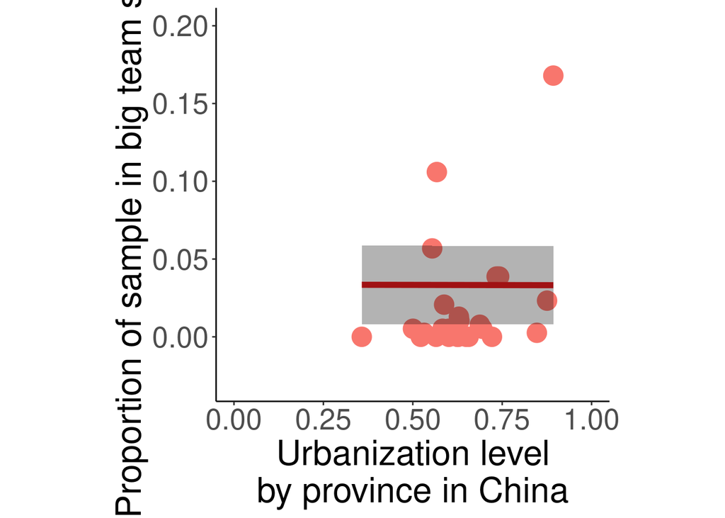

```r
model <- lm(Ruggeri_CN_pro ~ CN_UP_2020, data = CN_urbanization)
predict_data_CN <- data.frame(CN_UP_2020= CN_urbanization$CN_UP_2020, Ruggeri_CN_pro = CN_urbanization$Ruggeri_CN_pro )
predict_data_CN$predicted <- predict(model, newdata = predict_data_CN)
predict_data_CN$lower <- predict(model, newdata = CN_urbanization, interval = "confidence")[, "lwr"]
predict_data_CN$upper <- predict(model, newdata = CN_urbanization, interval = "confidence")[, "upr"]

CN_UP <- ggplot(data = CN_urbanization, aes(y = Ruggeri_CN_pro, x = CN_UP_2020, color = "#E41A1C")) +
  geom_point(stat = "identity", position = "identity", size = 6) +
  geom_line(data = predict_data_CN, aes(y = predicted), color = "#E41A1C", size = 2) +
  geom_ribbon(data = predict_data_CN, aes(ymin = lower, ymax = upper), fill = "black", alpha = 0.3, linetype = "blank") +
  ylab("Proportion of sample in big team science") +
  xlab("Urbanization level\nby province in China") +
  theme(axis.text = element_text(size = 20),
        axis.title = element_text(size = 24),
        panel.background = element_rect(fill = "white"),
        axis.line = element_line(color = "black"),
        aspect.ratio = 1) +
  xlim(c(0, 1)) +
  ylim(c(-0.03, 0.2)) +
  guides(color = FALSE)

CN_UP
```

```r
# Save the plot as a pdf image
# ggsave(filename = "CN_UP.jpg", plot = CN_UP, device = "pdf", width = 12, height = 12)
```

## the United States drawing (Urbanization)

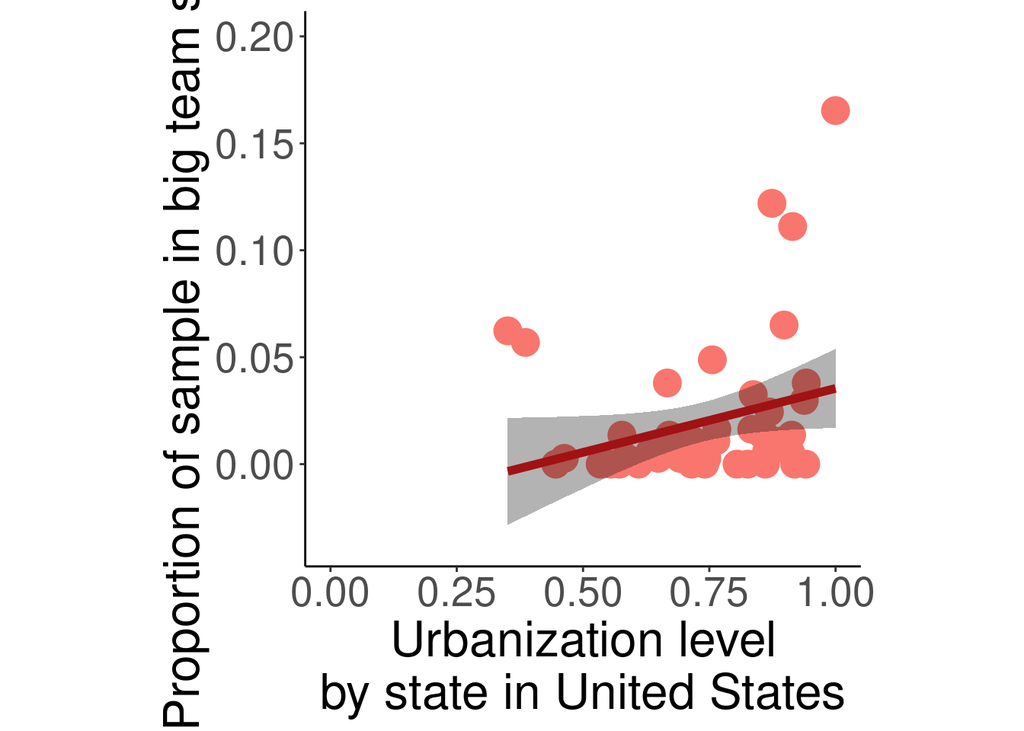

```r
model <- lm(Ruggeri_US_pro ~ US_UP_2020, data = US_urbanization)
predict_data_US <- data.frame(US_UP_2020= US_urbanization$US_UP_2020, Ruggeri_US_pro = US_urbanization$Ruggeri_US_pro )
predict_data_US$predicted <- predict(model, newdata = predict_data_US)
predict_data_US$lower <- predict(model, newdata = US_urbanization, interval = "confidence")[, "lwr"]
predict_data_US$upper <- predict(model, newdata = US_urbanization, interval = "confidence")[, "upr"]

US_UP <- ggplot(data = US_urbanization, aes(y = Ruggeri_US_pro, x = US_UP_2020, color = "#E41A1C")) +
  geom_point(stat = "identity", position = "identity", size = 6) +
  geom_line(data = predict_data_US, aes(y = predicted), color = "#E41A1C", size = 2) +
  geom_ribbon(data = predict_data_US, aes(ymin = lower, ymax = upper), fill = "black", alpha = 0.3, linetype = "blank") +
  ylab("Proportion of sample in big team science") +
  xlab("Urbanization level\nby state in United States") +
  theme(axis.text = element_text(size = 20),
        axis.title = element_text(size = 24),
        panel.background = element_rect(fill = "white"),
        axis.line = element_line(color = "black"),
        aspect.ratio = 1) +
  xlim(c(0, 1)) +
  ylim(c(-0.036, 0.2)) +
  guides(color = FALSE)

US_UP
```

```r
# Save the plot as a pdf image
# ggsave(filename = " US_UP.jpg", plot = US_UP, device = "pdf", width = 12, height = 12)
```

## Internet penetration rate drawing by state/province in Nigeria, China, and the United States

### Nigeria drawing (Internet penetration rate)

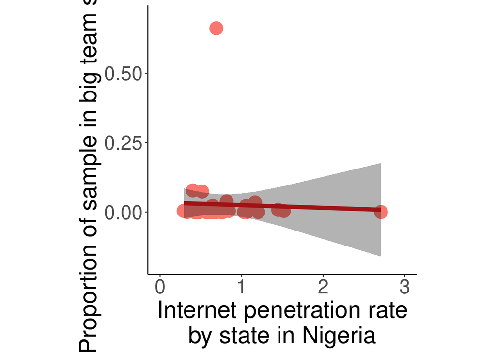

```r
# 拟合线性回归模型并计算置信区间
model <- lm(Ruggeri_NG_pro ~ Internet_NG_2022, data = NG_internet)
predict_data_NG <- data.frame(Internet_NG_2022 = NG_internet$Internet_NG_2022, Ruggeri_NG_pro = NG_internet$Ruggeri_NG_pro )
predict_data_NG$predicted <- predict(model, newdata = predict_data_NG)
predict_data_NG$lower <- predict(model, newdata = NG_internet, interval = "confidence")[, "lwr"]
predict_data_NG$upper <- predict(model, newdata = NG_internet, interval = "confidence")[, "upr"]

# 绘制散点图和回归线
NG_IPR <- ggplot(data = NG_internet, aes(y = Ruggeri_NG_pro, x = Internet_NG_2022, color = "#E41A1C")) +
  geom_point(stat = "identity", position = "identity", size = 6) +
  geom_line(data = predict_data_NG, aes(y = predicted), color = "#E41A1C", size = 2) +
  geom_ribbon(data = predict_data_NG, aes(ymin = lower, ymax = upper), fill = "black", alpha = 0.3, linetype = "blank") +
  ylab("Proportion of sample in big team science") +
  xlab("Internet penetration rate\nby state in Nigeria") +
  theme(axis.text = element_text(size = 20),
        axis.title = element_text(size = 24),
        panel.background = element_rect(fill = "white"),
        axis.line = element_line(color = "black"),
        aspect.ratio = 1) +
  xlim(c(0, 3)) +
  ylim(c(-0.18, 0.7)) +
  guides(color = FALSE)

NG_IPR
```

```r
# Save the plot as a JPEG image
ggsave(filename = "NG_IPR.jpg", plot = NG_IPR, device = "jpg", width = 12, height = 12)
```

### China drawing (Internet penetration rate)

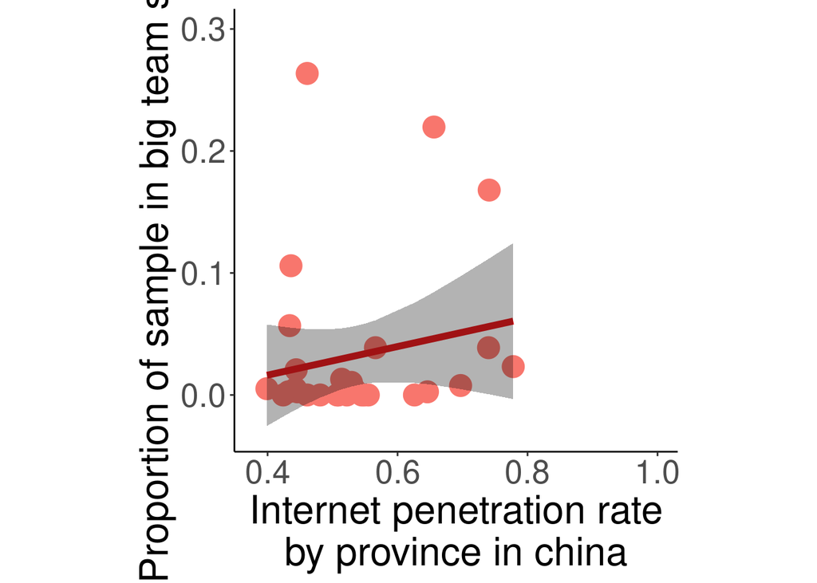

```r
# 拟合线性回归模型并计算置信区间
model <- lm(Ruggeri_CN_pro ~ Internet_CN_2016, data = CN_internet)
predict_data_CN <- data.frame(Internet_CN_2016= CN_internet$Internet_CN_2016, Ruggeri_CN_pro = CN_internet$Ruggeri_CN_pro )
predict_data_CN$predicted <- predict(model, newdata = predict_data_CN)
predict_data_CN$lower <- predict(model, newdata = CN_internet, interval = "confidence")[, "lwr"]
predict_data_CN$upper <- predict(model, newdata = CN_internet, interval = "confidence")[, "upr"]

# 绘制散点图和回归线
CN_IPR <- ggplot(data = CN_internet, aes(y = Ruggeri_CN_pro, x = Internet_CN_2016, color = "#E41A1C")) +
  geom_point(stat = "identity", position = "identity", size = 6) +
  geom_line(data = predict_data_CN, aes(y = predicted), color = "#E41A1C", size = 2) +
  geom_ribbon(data = predict_data_CN, aes(ymin = lower, ymax = upper), fill = "black", alpha = 0.3, linetype = "blank") +
  ylab("Proportion of sample in big team science") +
  xlab("Internet penetration rate\nby province in china") +
  theme(axis.text = element_text(size = 20),
        axis.title = element_text(size = 24),
        panel.background = element_rect(fill = "white"),
        axis.line = element_line(color = "black"),
        aspect.ratio = 1) +
  xlim(c(0.38, 1)) +
  ylim(c(-0.03, 0.3)) +
  guides(color = FALSE)

CN_IPR
```

```r
# Save the plot as a JPEG image
#ggsave(filename = "CN_IPR.jpg", plot = CN_IPR, device = "jpg", width = 12, height = 12)
```

### the United States drawing (Internet penetration rate)

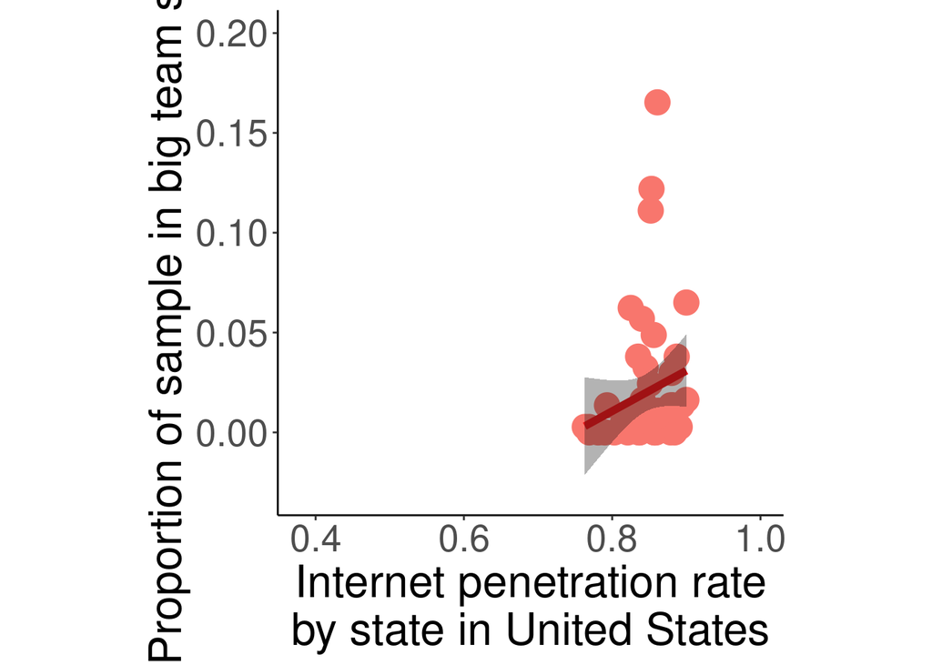

```r
model <- lm(Ruggeri_US_pro ~ Internet_US_2018, data = US_internet)
predict_data_US <- data.frame(Internet_US_2018= US_internet$Internet_US_2018, Ruggeri_US_pro = US_internet$Ruggeri_US_pro )
predict_data_US$predicted <- predict(model, newdata = predict_data_US)
predict_data_US$lower <- predict(model, newdata = US_internet, interval = "confidence")[, "lwr"]
predict_data_US$upper <- predict(model, newdata = US_internet, interval = "confidence")[, "upr"]

US_IPR <- ggplot(data = US_internet, aes(y = Ruggeri_US_pro, x = Internet_US_2018, color = "#E41A1C")) +
  geom_point(stat = "identity", position = "identity", size = 6) +
  geom_line(data = predict_data_US, aes(y = predicted), color = "#E41A1C", size = 2) +
  geom_ribbon(data = predict_data_US, aes(ymin = lower, ymax = upper), fill = "black", alpha = 0.3, linetype = "blank") +
  ylab("Proportion of sample in big team science") +
  xlab("Internet penetration rate\nby state in United States") +
  theme(axis.text = element_text(size = 20),
        axis.title = element_text(size = 24),
        panel.background = element_rect(fill = "white"),
        axis.line = element_line(color = "black"),
        aspect.ratio = 1) +
  xlim(c(0.38, 1)) +
  ylim(c(-0.03, 0.2)) +
  guides(color = FALSE)

US_IPR
```

```r
# Save the plot as a JPEG image
#ggsave(filename = "US_IPR.jpg", plot = US_IPR, device = "jpg", width = 12, height = 12)
```

## English Proficiency drawing by state/province in Nigeria, China, and Netherlands

### Nigeria drawing (English Proficiency)

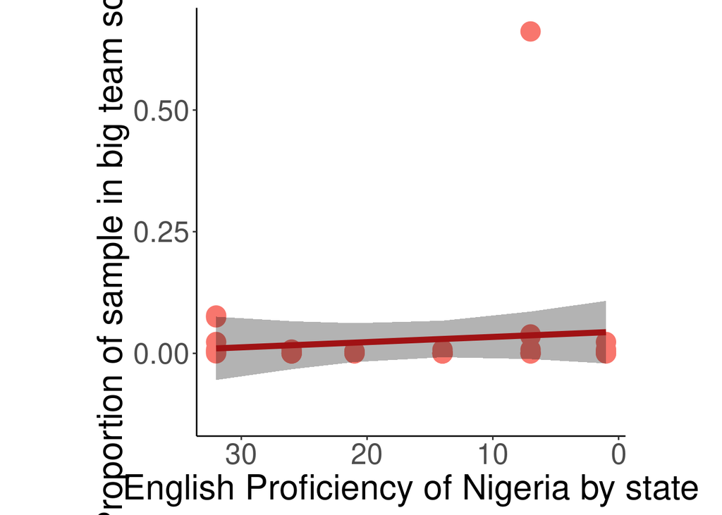

```r
model <- lm(Ruggeri_NG_pro ~ EPI_NG_2022, data = NG_EPI)
predict_data_NG <- data.frame(EPI_NG_2022 = NG_EPI$EPI_NG_2022, Ruggeri_NG_pro = NG_EPI$Ruggeri_NG_pro )

predict_data_NG$predicted <- predict(model, newdata = predict_data_NG)
predict_data_NG$lower <- predict(model, newdata = NG_EPI, interval = "confidence")[, "lwr"]
predict_data_NG$upper <- predict(model, newdata = NG_EPI, interval = "confidence")[, "upr"]

NG_EPI <- ggplot(data = NG_EPI, aes(y = Ruggeri_NG_pro, x = EPI_NG_2022, color = "#E41A1C")) +
  geom_point(stat = "identity", position = "identity", size = 6) +
  geom_line(data = predict_data_NG, aes(y = predicted), color = "#E41A1C", size = 2) +
  geom_ribbon(data = predict_data_NG, aes(ymin = lower, ymax = upper), fill = "black", alpha = 0.3, linetype = "blank") +
  ylab("Proportion of sample in big team science") +
  xlab("English Proficiency of Nigeria by state") +
  theme(axis.text = element_text(size = 20),
        axis.title = element_text(size = 24),
        panel.background = element_rect(fill = "white"),
        axis.line = element_line(color = "black"),
        aspect.ratio = 1) +
  xlim(c(470, 670)) +
  ylim(c(-0.13, 0.67)) +
  guides(color = FALSE)
#turn over X-axis
NG_EPI <- NG_EPI + scale_x_reverse()
NG_EPI
```

```r
# Save the plot as a JPEG image
# ggsave(filename = " NG_EPI.jpg", plot = NG_EPI, device = "jpg", width = 12, height = 12)
```

### China drawing (English Proficiency)

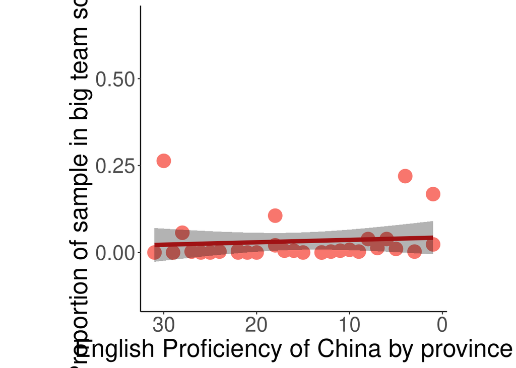

```r
model <- lm(Ruggeri_CN_pro ~ EPI_CN_2022, data = CN_EPI)
predict_data_CN <- data.frame(EPI_CN_2022 = CN_EPI$EPI_CN_2022, Ruggeri_CN_pro = CN_EPI$Ruggeri_CN_pro )
predict_data_CN$predicted <- predict(model, newdata = predict_data_CN)
predict_data_CN$lower <- predict(model, newdata = CN_EPI, interval = "confidence")[, "lwr"]
predict_data_CN$upper <- predict(model, newdata = CN_EPI, interval = "confidence")[, "upr"]

CN_EPI <- ggplot(data = CN_EPI, aes(y = Ruggeri_CN_pro, x = EPI_CN_2022, color = "#E41A1C")) +
  geom_point(stat = "identity", position = "identity", size = 6) +
  geom_line(data = predict_data_CN, aes(y = predicted), color = "#E41A1C", size = 2) +
  geom_ribbon(data = predict_data_CN, aes(ymin = lower, ymax = upper), fill = "black", alpha = 0.3, linetype = "blank") +
  ylab("Proportion of sample in big team science") +
  xlab("English Proficiency of China by province") +
  theme(axis.text = element_text(size = 20),
        axis.title = element_text(size = 24),
        panel.background = element_rect(fill = "white"),
        axis.line = element_line(color = "black"),
        aspect.ratio = 1) +
  xlim(c(0, 32)) +
  ylim(c(-0.13, 0.67)) +
  guides(color = FALSE)

#turn over X-axis
CN_EPI <- CN_EPI + scale_x_reverse()
CN_EPI
```

```r
# Save the plot as a JPEG image
ggsave(filename = " CN_EPI.jpg", plot = CN_EPI, device = "jpg", width = 12, height = 12)
```

### Netherlands drawing (English Proficiency)

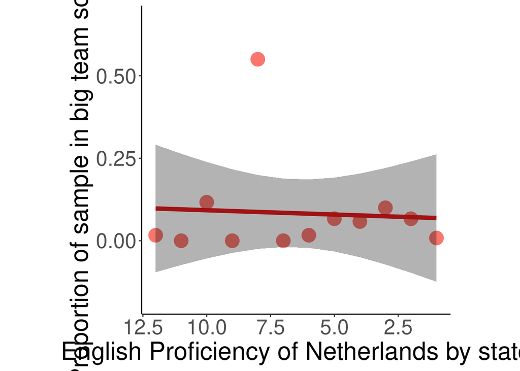

```r
model <- lm(Ruggeri_NL_pro ~ EPI_NL_2022, data = NL_EPI)
predict_data_NL <- data.frame(EPI_NL_2022 = NL_EPI$EPI_NL_2022, Ruggeri_NL_pro = NL_EPI$Ruggeri_NL_pro )
predict_data_NL$predicted <- predict(model, newdata = predict_data_NL)
predict_data_NL$lower <- predict(model, newdata = NL_EPI, interval = "confidence")[, "lwr"]
predict_data_NL$upper <- predict(model, newdata = NL_EPI, interval = "confidence")[, "upr"]

NL_EPI <- ggplot(data = NL_EPI, aes(y = Ruggeri_NL_pro, x = EPI_NL_2022, color = "#E41A1C")) +
  geom_point(stat = "identity", position = "identity", size = 6) +
  geom_line(data = predict_data_NL, aes(y = predicted), color = "#E41A1C", size = 2) +
  geom_ribbon(data = predict_data_NL, aes(ymin = lower, ymax = upper), fill = "black", alpha = 0.3, linetype = "blank") +
  ylab("Proportion of sample in big team science") +
  xlab("English Proficiency of Netherlands by state") +
  theme(axis.text = element_text(size = 20),
        axis.title = element_text(size = 24),
        panel.background = element_rect(fill = "white"),
        axis.line = element_line(color = "black"),
        aspect.ratio = 1) +
  xlim(c(0, 32)) +
  ylim(c(-0.18, 0.67)) +
  guides(color = FALSE)
#turn over X-axis
NL_EPI <- NL_EPI + scale_x_reverse()
NL_EPI
```

```r
# Save the plot as a JPEG image
ggsave(filename = " NL_EPI.jpg", plot = NL_EPI, device = "jpg", width = 12, height = 12)
```

Merge the figures

[figure not shown]

```r
# Arrange 9 graphics horizontally, left and right
combined_plot2 <- KE_UP + CN_UP + US_UP + NG_IPR + CN_IPR + US_IPR + NG_EPI + CN_EPI + NL_EPI+
  patchwork::plot_layout(ncol = 3) +
patchwork::plot_annotation(tag_levels ="A",
                  theme = theme(plot.title = element_text(size = 26)))

combined_plot2
```

```r
# Save the plot as a pdf image
ggsave(filename = "Exploratory_analyses_by_state.pdf", plot = combined_plot2, device = "pdf", width = 24, height = 24)
```